# DCD Survival Analysis

Pediatric Heart

Modified

November 19, 2025

# 1 Population

```r
# Pediatric heart candidates
patients = read_rds(file.path(dir_data, "patients.rds"))
# offers made to pediatric heart candidates
offers = read_rds(file.path(dir_data, "offers.rds"))
# waitlist data for pediatric heart candidates
waitlists = read_rds(file.path(dir_data, "waitlist.rds"))
```

```r
## Fix waitlists

# Last Match Run: 2024-06-30 23:59:59
# Last waitlist record: 2024-07-05 16:00:00
# 1. Remove waitlist records after 2024-06-30 (since we can't see the offers)
# 2. add CHG_TY = D and CHG_DT = 2024-06-30 23:59:59 for still on waitlist patients
# 3. Fill down values for the new data.

waitlists =
  waitlists %>%
  filter(
    as.Date(CHG_DT) <= as.Date("2024-06-30")
  ) %>%
  complete(WL_ID_CODE, CHG_TY = "D") %>%
  mutate(
    CHG_DT = coalesce(CHG_DT, lubridate::ymd_hms("2024-06-30 23:59:59"))
  ) %>%
  arrange(CHG_DT) %>%
  group_by(WL_ID_CODE) %>%
    fill(everything(), .direction = "down") %>%
  ungroup()
```

The primary patient (candidate/recipient) population is: **all pediatric HR candidates listed between 2021-01-01 and 2024-06-30**

- pediatric: Under 18 at *time of listing*
- HR: using heart (HR) waitlists. Some patients listed for both HR and HL.
- Waitlist initiated between: 2021-01-01 and 2024-06-30

```r
n_pt = patients$WL_ID_CODE %>% n_distinct()
n_wl = waitlists$WL_ID_CODE %>% n_distinct()
n_off = offers$WL_ID_CODE %>% n_distinct()
```

There are $n = 2486$ unique patients/waitlists. And $2271$ of these patients received an offer during their time on the waitlist.

## 1.1 Transplants

```r
patients %>%
  mutate(
    TX = ifelse(TXED == 1, "Transplanted", "Not Transplanted"),
    DCD_DONOR = case_when(
      DCD_DON == "Y" ~ "Yes",
      DCD_DON == "N" ~ "No",
      TX == "Not Transplanted" ~ "-",
      .default = "Unknown"
    )
  ) %>%
  count(TX, DCD_DONOR) %>%
  gt()
```

| TX | DCD_DONOR | n |
| --- | --- | --- |
| Not Transplanted | - | 893 |
| Transplanted | No | 1566 |
| Transplanted | Unknown | 6 |
| Transplanted | Yes | 21 |

# 2 DCD Population

## 2.1 DCD Recipients (Transplants)

### 2.1.1 By Age (Listing and TX)

```r
patients %>%
  filter(DCD_DON == "Y") %>%
  count(AGE_AT_LISTING, AGE_AT_TX) %>% gt()
```

| WL AGE AT LISTING IN YEARS | Recipient Age | n |
| --- | --- | --- |
| 0 | 0 | 8 |
| 1 | 1 | 1 |
| 4 | 4 | 1 |
| 4 | 5 | 1 |
| 6 | 7 | 1 |
| 9 | 9 | 1 |
| 9 | 10 | 1 |
| 13 | 13 | 2 |
| 14 | 14 | 4 |
| 17 | 20 | 1 |

### 2.1.2 By Year

```r
patients %>%
  filter(DCD_DON == "Y") %>%
  count(TX_YEAR) %>% gt()
```

| TRANSPLANT YEAR | n |
| --- | --- |
| 2021 | 1 |
| 2022 | 3 |
| 2023 | 10 |
| 2024 | 7 |

Notes:

- we only have data through 2024-06-30, so 2024 counts are about half of expected.
- we may want to exclude the 20 year old DCD transplant that occurred in 2023.

### 2.1.3 By Year and Age

```r
patients %>%
  filter(DCD_DON == "Y") %>%
  count(TX_YEAR, AGE_AT_TX) %>%
  spread(AGE_AT_TX, n, fill = "-") %>%
  gt() %>% tab_spanner(
    label = "Recipient Age",
    columns = -1
  )
```

| TRANSPLANT YEAR | Recipient Age 0 | Recipient Age 1 | Recipient Age 4 | Recipient Age 5 | Recipient Age 7 | Recipient Age 9 | Recipient Age 10 | Recipient Age 13 | Recipient Age 14 | Recipient Age 20 |
| --- | --- | --- | --- | --- | --- | --- | --- | --- | --- | --- |
| 2021 | - | - | - | - | - | - | - | - | 1 | - |
| 2022 | 2 | - | - | 1 | - | - | - | - | - | - |
| 2023 | 4 | 1 | 1 | - | 1 | - | 1 | 1 | - | 1 |
| 2024 | 2 | - | - | - | - | 1 | - | 1 | 3 | - |

Notes:

- we may want to exclude the 20 year old DCD transplant that occurred in 2023.

## 2.2 DCD Eligible Candidates

Number of Pediatric Candidates open to see offers for DCD heart (`WL_DCD_SEQ`).

- `No`: never open to see DCD offers
- `Yes`: always open to see DCD offers
- `No -> Yes`: initially listed as not accepting DCD offers, but changed to consider.
- `Yes -> No`: initially listed as accepting DCD offers, but changed to no longer consider.

```r
# Open to DCD offers during time on WL
WL_DCD =
  waitlists %>%
  arrange(CHG_DT) %>%
  distinct(WL_ID_CODE, DONCRIT_ACPT_DCD) %>%
  mutate(
    DONCRIT_ACPT_DCD = case_match(DONCRIT_ACPT_DCD, "N" ~ "No", "Y" ~ "Yes")
  ) %>%
  summarize(
    .by = WL_ID_CODE,
    WL_DCD_SEQ = str_c(DONCRIT_ACPT_DCD, collapse = " -> ")
  )
```

```r
WL_DCD %>%
  count(WL_DCD_SEQ) %>%
  mutate( p = scales::percent(n/sum(n), 1/10) ) %>% gt()
```

| WL_DCD_SEQ | n | p |
| --- | --- | --- |
| No | 2353 | 94.7% |
| No -> Yes | 47 | 1.9% |
| Yes | 71 | 2.9% |
| Yes -> No | 15 | 0.6% |

Note: This **includes** about $n=26$ candidates who turned 18 while on the waitlist.

# 3 Post-Tx Outcomes

To measure post transplant outcomes, we exclude recipients who don’t have a transplant date.

```r
n_no_txdate = patients %>% filter(TXED == 1) %>% filter(is.na(TX_DATE))  %>% nrow()
```

This excludes $n = 6$ recipients.

Removing data for patients that were adult (AGE_AT_TX >= 18) **at time of transplant**.

```r
n_turned_18 = patients %>%  filter(AGE_AT_TX >= 18) %>% nrow()
```

This excludes $n = 45$ recipients.

```r
post_tx =
  patients %>%
  filter(AGE_AT_TX < 18) %>%
  filter(TXED == 1) %>%        # only transplants
  filter(!is.na(TX_DATE)) %>%  # not missing transplant date
  mutate(
    EV_TIME = coalesce(EV_TIME, 0), # set EV_TIME = 0 if missing
    EV_TYPE = coalesce(EV_TYPE, 0)  # set EV_TYPE = 0 if missing
  ) %>%
  left_join(WL_DCD, by = "WL_ID_CODE")
```

This leaves $n = 1540$ recipients in our post-tx data.

## 3.1 Transplant recipients by year and DCD Donor

```r
post_tx %>%
  count(TX_YEAR, DCD_DON = case_match(DCD_DON, "N" ~ "No", "Y" ~ "Yes" )) %>%
  spread(DCD_DON, n) %>%
  gt() %>%
  tab_spanner(
    label = "DCD Donor",
    columns = -1
  )
```

| TRANSPLANT YEAR | DCD Donor No | DCD Donor Yes |
| --- | --- | --- |
| 2021 | 328 | 1 |
| 2022 | 462 | 3 |
| 2023 | 489 | 9 |
| 2024 | 241 | 7 |

## 3.2 Transplant recipients by year and DCD Donor and Outcome

Note:

```r
post_tx %>%
  filter(EV_TIME > 0) %>%   # Ignore transplants with no follow-up
  count(
    TX_YEAR,
    DCD_DON = case_match(DCD_DON, "N" ~ "DBD", "Y" ~ "DCD" ),
    EV_TYPE = case_match(EV_TYPE, 0 ~ "Alive/Censored", 1 ~ "Death or Graft Failure"),
  ) %>%
  complete(
    TX_YEAR, DCD_DON, EV_TYPE, fill = list(n=0L)
  ) %>%
  mutate(
    .by = c(TX_YEAR, DCD_DON),
    p = (n / sum(n)) %>% scales::percent(.1),
    p = str_pad(p, width = 6, side = "left"),
    n = glue::glue("{n} ({p})"),
    n = str_pad(n, width = 12, side = "left")
  ) %>%
  select(-p) %>%
  spread(
    DCD_DON, n
  ) %>%
  rename(Outcome = EV_TYPE) %>%
  gt(
    groupname_col = "TX_YEAR",
    row_group_as_column = TRUE,
  ) %>%
  tab_spanner(
    label = "Donor Type",
    columns = 3:4
  )
```

|  | Outcome | Donor Type DBD | Donor Type DCD |
| --- | --- | --- | --- |
| 2021 | Alive/Censored | 288 ( 88.1%) | 1 (100.0%) |
|  | Death or Graft Failure | 39 ( 11.9%) | 0 ( 0.0%) |
| 2022 | Alive/Censored | 407 ( 88.5%) | 3 (100.0%) |
|  | Death or Graft Failure | 53 ( 11.5%) | 0 ( 0.0%) |
| 2023 | Alive/Censored | 449 ( 92.8%) | 7 ( 77.8%) |
|  | Death or Graft Failure | 35 ( 7.2%) | 2 ( 22.2%) |
| 2024 | Alive/Censored | 146 ( 97.3%) | 3 (100.0%) |
|  | Death or Graft Failure | 4 ( 2.7%) | 0 ( 0.0%) |

## 3.3 Survival Analysis (Kaplan-Meier)

Note: there is not enough DCD transplants or follow-up time to allow conclusive statements.

```r
library(survival)

tmp = post_tx %>%
  #filter(EV_TIME > 0) %>%
  mutate(
    DCD_DON = case_match(DCD_DON, "N" ~ "DBD", "Y" ~ "DCD" )
  ) %>%
  mutate(S = Surv(EV_TIME, EV_TYPE))

kmfit = survfit(S~DCD_DON, data = tmp)
```

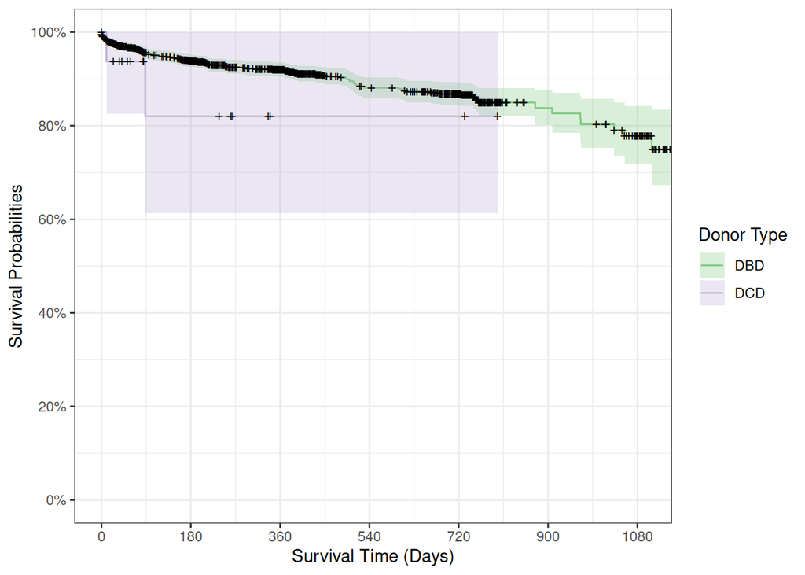

```r
library(ggfortify)
autoplot(
  kmfit,
  conf.int = TRUE,
  grid = FALSE,
) +
  scale_fill_brewer(type = "qual") +
  scale_color_brewer(type = "qual") +
  labs(
    x = "Survival Time (Days)",
    y = "Survival Probabilities",
    fill = "Donor Type",
    color = "Donor Type"
    ) +
  scale_y_continuous(breaks = seq(0, 1, by = .20), labels = scales::percent) +
  scale_x_continuous(breaks = seq(0, 1500, by = 180), limits = c(NA, 365*4))  +
  coord_cartesian(xlim = c(0, 365*3), ylim = c(0, 1)) +
  theme_bw()
```

## 3.4 Survival Plot (Individual)

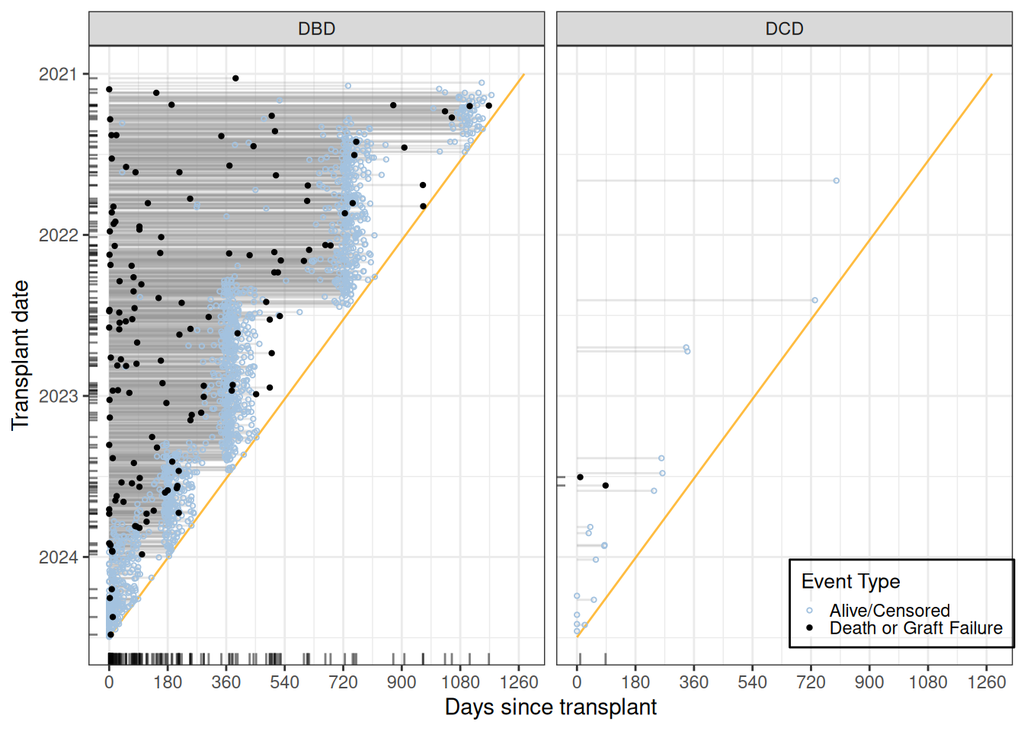

```r
days_observed =
  tibble(
    TX_DATE = seq(as.Date("2021-01-01"), as.Date("2024-07-01"), by = "1 day"),
    days = difftime(as.Date("2024-07-01"), TX_DATE, units = "days") %>%
      as.numeric()
  )

event_labels = c("Alive/Censored", "Death or Graft Failure")

post_tx %>%
  transmute(
    AGE_AT_TX,
    STATUS_AT_TX,
    TX_YEAR,
    TX_DATE,
    DCD_DON = case_match(DCD_DON, "N" ~ 'DBD', "Y" ~ "DCD"),
    WL_DCD_SEQ,
    EV_TIME,
    EV_TYPE = factor(EV_TYPE), # = case_match(EV_TYPE, 1 ~ "Death or Graft Failure", 0 ~ "Censored"),
  ) %>%
  ggplot(aes(x = 0, xend = EV_TIME, y = TX_DATE, yend = TX_DATE)) +
  facet_wrap(~DCD_DON) +
  geom_line(data = days_observed, aes(x = days, y = TX_DATE), color = "orange", alpha = .75, inherit.aes = FALSE) +
  geom_segment(alpha = .25, color = "grey60") +
  # plot censored events first so events show more clearly
  geom_point(data = . %>% filter(EV_TYPE == 0),
             aes(x = EV_TIME, color = EV_TYPE, shape = EV_TYPE),
             size = .8) +
  geom_point(data = . %>% filter(EV_TYPE == 1),
             aes(x = EV_TIME, color = EV_TYPE, shape = EV_TYPE),
             size = .8) +
  scale_shape_manual(values = c(1, 19), labels = event_labels) +
  scale_color_manual(values = c("#A3C2DF", "black"), labels = event_labels) +
  geom_rug(data = . %>% filter(EV_TYPE == 1), aes(x = EV_TIME), alpha = .50, length = unit(.02, "npc")) +
  scale_x_continuous(breaks = seq(0, 1500, by = 180)) +
  scale_y_continuous(
    trans = c("date", "reverse")
  ) +
  labs(
    x = "Days since transplant",
    y = "Transplant date",
    color = "Event Type",
    shape = "Event Type"
  ) +
   theme(
     legend.position = "inside",
     legend.position.inside = c(.88, 1-.90),
     legend.key.size = unit(0.3, "cm"),
     legend.background = element_rect(color = "black", fill = "transparent"),
     legend.title = element_text(size = 10)
   )
```

## 3.5 Other post-tx comparison ideas

I did try to implement a causal survival forest to estimate the change in survival probability (or mean survival time) due to DCD donor. However, there isn’t enough DCD data to avoid the copious warnings that results are unstable. FYI - there was no detected change in survival using DCD, but again, this isn’t very meaningful due to the limited sample size.

Another idea is to fit a cox survival model to the DBD recipients (using all covariates) and predict the survival time for the DCD recipients. We can evaluate if DCD survival is longer/shorter than expected.

## 3.6 DCD Recipients vs. DCD Candidates

There are some DCD candidates that ended up getting DBD hearts. This is an interesting group because if there are differences in a patients that prompts their listing centers to accept DCD, this can account for it. In other words compare outcomes for DCD candidates that received DBD vs. received DCD hearts.

Note: removed transplants with no follow-up data.

```r
post_tx %>%
  count(DCD_DON = case_match(DCD_DON, "N" ~ "DBD", "Y" ~ "DCD" ), WL_DCD_SEQ) %>%
  mutate(
    WL_DCD_SEQ = factor(WL_DCD_SEQ, levels = c("No", "Yes -> No", "No -> Yes", "Yes"))
  ) %>%
  arrange(WL_DCD_SEQ, DCD_DON) %>%
  spread(DCD_DON, n, fill = 0L) %>%
  gt()
```

| WL_DCD_SEQ | DBD | DCD |
| --- | --- | --- |
| No | 1455 | 0 |
| Yes -> No | 9 | 0 |
| No -> Yes | 24 | 6 |
| Yes | 32 | 14 |

```r
post_tx %>%
  filter(EV_TIME > 0) %>%   # Ignore transplants with no follow-up
  filter(WL_DCD_SEQ %in% c("Yes", "No -> Yes")) %>%
  count(
    WL_DCD_SEQ,
    DCD_DON = case_match(DCD_DON, "N" ~ "DBD", "Y" ~ "DCD" ),
    EV_TYPE = case_match(EV_TYPE, 0 ~ "Alive/Censored", 1 ~ "Death or Graft Failure"),
  ) %>%
  complete(
    WL_DCD_SEQ, DCD_DON, EV_TYPE, fill = list(n=0L)
  ) %>%
  mutate(
    .by = c(WL_DCD_SEQ, DCD_DON),
    p = (n / sum(n)) %>% scales::percent(.1),
    p = str_pad(p, width = 6, side = "left"),
    n = glue::glue("{n} ({p})"),
    n = str_pad(n, width = 12, side = "left")
  ) %>%
  select(-p) %>%
  spread(
    DCD_DON, n
  ) %>%
  rename(Outcome = EV_TYPE) %>%
  gt(
    groupname_col = "WL_DCD_SEQ",
    row_group_as_column = TRUE,
  ) %>%
  tab_spanner(
    label = "Donor Type",
    columns = 3:4
  )
```

|  | Outcome | Donor Type DBD | Donor Type DCD |
| --- | --- | --- | --- |
| No -> Yes | Alive/Censored | 16 ( 88.9%) | 4 ( 80.0%) |
|  | Death or Graft Failure | 2 ( 11.1%) | 1 ( 20.0%) |
| Yes | Alive/Censored | 30 ( 93.8%) | 10 ( 90.9%) |
|  | Death or Graft Failure | 2 ( 6.2%) | 1 ( 9.1%) |

### 3.6.1 DCD-Recipient (DCD-R) vs DCD-Listed-DBD-Recipient (DCD-L)

Using all information up to June 2024.

```r
post_tx %>%
  filter(EV_TIME > 0) %>%   # Ignore transplants with no follow-up
  filter(WL_DCD_SEQ %in% c("Yes", "No -> Yes")) %>%
  count(
    #WL_DCD_SEQ,
    DCD_DON = case_match(DCD_DON, "N" ~ "DCD-L", "Y" ~ "DCD-R" ),
    EV_TYPE = case_match(EV_TYPE, 0 ~ "Alive/Censored", 1 ~ "Death or Graft Failure"),
  ) %>%
  complete(
    #WL_DCD_SEQ,
    DCD_DON, EV_TYPE, fill = list(n=0L)
  ) %>%
  mutate(
    #.by = c(WL_DCD_SEQ, DCD_DON),
    .by = DCD_DON,
    p = (n / sum(n)) %>% scales::percent(.1),
    p = str_pad(p, width = 6, side = "left"),
    n = glue::glue("{n} ({p})"),
    n = str_pad(n, width = 12, side = "left")
  ) %>%
  select(-p) %>%
  spread(
    DCD_DON, n
  ) %>%
  rename(Outcome = EV_TYPE) %>%
  gt(
    #groupname_col = "WL_DCD_SEQ",
    #row_group_as_column = TRUE,
  ) %>%
  tab_spanner(
    label = "Donor Type",
    columns = 2:3
  )
```

| Outcome | Donor Type DCD-L | Donor Type DCD-R |
| --- | --- | --- |
| Alive/Censored | 46 ( 92.0%) | 14 ( 87.5%) |
| Death or Graft Failure | 4 ( 8.0%) | 2 ( 12.5%) |

Only looking at outcomes at 30 days post-transplant.

```r
post_tx %>%
  filter(EV_TIME > 0) %>%   # Ignore transplants with no follow-up
  filter(WL_DCD_SEQ %in% c("Yes", "No -> Yes")) %>%
  # 30 day outcomes:
  mutate(
    EV_TYPE = case_when(
      EV_TIME > 30 ~ 0L,                 # alive at time 30
      EV_TIME <= 30 & EV_TYPE == 1 ~ 1L, # death/failure by time 30
      EV_TIME <= 30 & EV_TYPE == 0 ~ 0L  # censored at time 30
    )
    ) %>%

  count(
    #WL_DCD_SEQ,
    DCD_DON = case_match(DCD_DON, "N" ~ "DCD-L", "Y" ~ "DCD-R" ),
    EV_TYPE = case_match(EV_TYPE, 0 ~ "Alive/Censored", 1 ~ "Death or Graft Failure"),
  ) %>%
  complete(
    #WL_DCD_SEQ,
    DCD_DON, EV_TYPE, fill = list(n=0L)
  ) %>%
  mutate(
    #.by = c(WL_DCD_SEQ, DCD_DON),
    .by = DCD_DON,
    p = (n / sum(n)) %>% scales::percent(.1),
    p = str_pad(p, width = 6, side = "left"),
    n = glue::glue("{n} ({p})"),
    n = str_pad(n, width = 12, side = "left")
  ) %>%
  select(-p) %>%
  spread(
    DCD_DON, n
  ) %>%
  rename(Outcome = EV_TYPE) %>%
  gt(
    #groupname_col = "WL_DCD_SEQ",
    #row_group_as_column = TRUE,
  ) %>%
  tab_spanner(
    label = "Donor Type",
    columns = 2:3
  )
```

| Outcome | Donor Type DCD-L | Donor Type DCD-R |
| --- | --- | --- |
| Alive/Censored | 50 (100.0%) | 15 ( 93.8%) |
| Death or Graft Failure | 0 ( 0.0%) | 1 ( 6.2%) |

```r
tab_30day_survival =
post_tx %>%
  filter(EV_TIME > 0) %>%   # Ignore transplants with no follow-up
  filter(WL_DCD_SEQ %in% c("Yes", "No -> Yes")) %>%
  # 30 day outcomes:
  mutate(
    EV_TYPE = case_when(
      EV_TIME > 30 ~ 0L,                 # alive at time 30
      EV_TIME <= 30 & EV_TYPE == 1 ~ 1L, # death/failure by time 30
      EV_TIME <= 30 & EV_TYPE == 0 ~ 0L  # censored at time 30
    )
    ) %>%

  count(
    #WL_DCD_SEQ,
    DCD_DON = case_match(DCD_DON, "N" ~ "DCD-L", "Y" ~ "DCD-R" ),
    EV_TYPE = case_match(EV_TYPE, 0 ~ "Alive/Censored", 1 ~ "Death or Graft Failure"),
  ) %>%
  complete(
    #WL_DCD_SEQ,
    DCD_DON, EV_TYPE, fill = list(n=0L)
  ) %>%
  spread(
    DCD_DON, n
  ) %>%
  select(-EV_TYPE)


# Fisher's Test
fisher.test(tab_30day_survival)
```

```
    Fisher's Exact Test for Count Data

data:  tab_30day_survival
p-value = 0.2424
alternative hypothesis: true odds ratio is not equal to 1
95 percent confidence interval:
 0.0801281       Inf
sample estimates:
odds ratio
       Inf
```

```r
# Chi-sq test
chisq.test(tab_30day_survival)
```

```
    Pearson's Chi-squared test with Yates' continuity correction

data:  tab_30day_survival
X-squared = 0.36681, df = 1, p-value = 0.5447
```

### 3.6.2 Kaplan-Meier Plots for DCD-Recipient (DCD-R) vs DCD-Listed-DBD-Recipient (DCD-L)

```r
library(survival)

tmp = post_tx %>%
  filter(EV_TIME > 0) %>%    # Ignore transplants with no follow-up
  filter(
    WL_DCD_SEQ %in% c("Yes", "No -> Yes")
  ) %>%
  mutate(
    DCD_DON = case_match(DCD_DON, "N" ~ "DCD-L", "Y" ~ "DCD-R" ),
  ) %>%
  mutate(S = Surv(EV_TIME, EV_TYPE))

kmfit = survfit(S~DCD_DON, data = tmp)
```

```r
stat_test = survdiff(S~DCD_DON, data = tmp)
```

The p-value for the survival difference is 0.382.

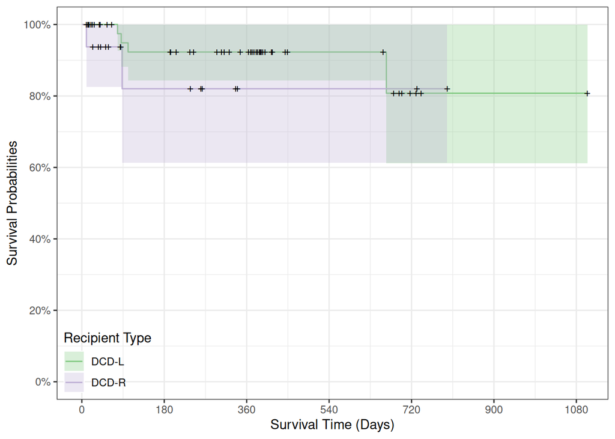

```r
library(ggfortify)
autoplot(
  kmfit,
  conf.int = TRUE,
  grid = FALSE,
) +
  scale_fill_brewer(type = "qual") +
  scale_color_brewer(type = "qual") +
  labs(
    x = "Survival Time (Days)",
    y = "Survival Probabilities",
    fill = "Recipient Type",
    color = "Recipient Type"
    ) +
  scale_y_continuous(breaks = seq(0, 1, by = .20), labels = scales::percent) +
  scale_x_continuous(breaks = seq(0, 1500, by = 180), limits = c(NA, 365*4))  +
  coord_cartesian(xlim = c(0, 365*3), ylim = c(0, 1)) +
  theme_bw() +
  theme(
    legend.position = "inside",
    legend.position.inside = c(0, 0),
    legend.background = element_blank(),
    legend.justification.inside = c(0,0)
  )
```

```r
eval_times = c(10, 30, 60, 90, seq(180, 1080, by = 180))

kmfit %>%
  summary(times = eval_times, data.frame = TRUE, extend = FALSE) %>%
  transmute(
    recipient = str_remove(strata, "DCD_DON="),
    days = time,
    n_at_risk = n.risk,
    n_events = n.event,
    survival_prob = surv,
    std_error = std.err,
    lower,
    upper
  )  %>%
  group_by(recipient) %>%
  gt(row_group_as_column = TRUE) %>%
  fmt_number(
    columns = c("survival_prob", "std_error", "lower", "upper"),
    decimals = 3
  ) %>%
  cols_align(
    align = "center",
    columns = row_group()
  )
```

|  | days | n_at_risk | n_events | survival_prob | std_error | lower | upper |
| --- | --- | --- | --- | --- | --- | --- | --- |
| DCD-L | 10 | 50 | 0 | 1.000 | 0.000 | 1.000 | 1.000 |
|  | 30 | 43 | 0 | 1.000 | 0.000 | 1.000 | 1.000 |
|  | 60 | 40 | 0 | 1.000 | 0.000 | 1.000 | 1.000 |
|  | 90 | 37 | 2 | 0.949 | 0.035 | 0.882 | 1.000 |
|  | 180 | 36 | 1 | 0.923 | 0.043 | 0.843 | 1.000 |
|  | 360 | 26 | 0 | 0.923 | 0.043 | 0.843 | 1.000 |
|  | 540 | 9 | 0 | 0.923 | 0.043 | 0.843 | 1.000 |
|  | 720 | 3 | 1 | 0.808 | 0.114 | 0.612 | 1.000 |
|  | 900 | 1 | 0 | 0.808 | 0.114 | 0.612 | 1.000 |
|  | 1080 | 1 | 0 | 0.808 | 0.114 | 0.612 | 1.000 |
| DCD-R | 10 | 16 | 1 | 0.938 | 0.061 | 0.826 | 1.000 |
|  | 30 | 14 | 0 | 0.938 | 0.061 | 0.826 | 1.000 |
|  | 60 | 10 | 0 | 0.938 | 0.061 | 0.826 | 1.000 |
|  | 90 | 7 | 1 | 0.820 | 0.122 | 0.613 | 1.000 |
|  | 180 | 7 | 0 | 0.820 | 0.122 | 0.613 | 1.000 |
|  | 360 | 2 | 0 | 0.820 | 0.122 | 0.613 | 1.000 |
|  | 540 | 2 | 0 | 0.820 | 0.122 | 0.613 | 1.000 |
|  | 720 | 2 | 0 | 0.820 | 0.122 | 0.613 | 1.000 |

### 3.6.3 With Administrative Censoring

```r
admin_censoring = 365*2 # 2 years
```

This using *administrative censoring* at 730 days.

```r
library(survival)

tmp = post_tx %>%
  filter(EV_TIME > 0) %>%    # Ignore transplants with no follow-up
  filter(
    WL_DCD_SEQ %in% c("Yes", "No -> Yes")
  ) %>%
  mutate(
    DCD_DON = case_match(DCD_DON, "N" ~ "DCD-L", "Y" ~ "DCD-R" ),
    EV_TYPE = ifelse(EV_TIME > admin_censoring , 0, EV_TYPE),
    EV_TIME = pmin(EV_TIME, admin_censoring),
  ) %>%
  mutate(S = Surv(EV_TIME, EV_TYPE))

kmfit = survfit(S~DCD_DON, data = tmp)
```

```r
stat_test = survdiff(S~DCD_DON, data = tmp)
```

The p-value for the survival difference is 0.382.

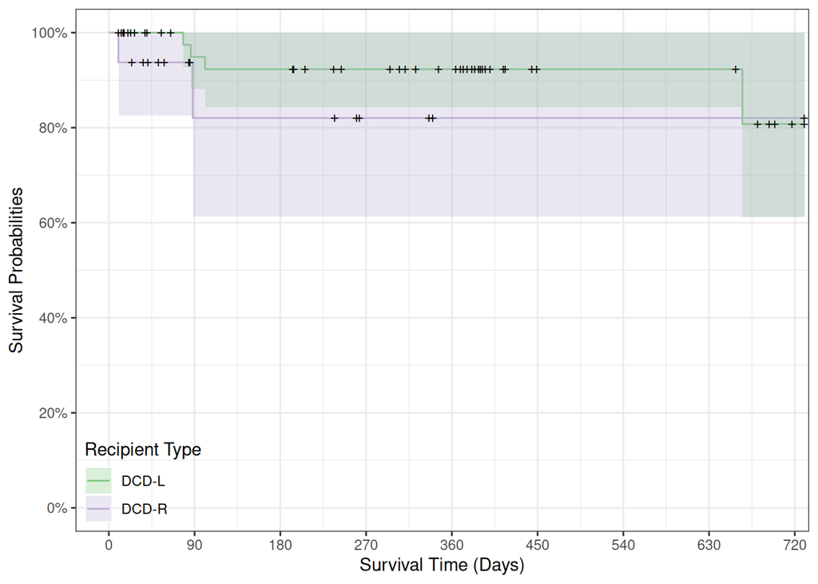

```r
library(ggfortify)
autoplot(
  kmfit,
  conf.int = TRUE,
  grid = FALSE,
) +
  scale_fill_brewer(type = "qual") +
  scale_color_brewer(type = "qual") +
  labs(
    x = "Survival Time (Days)",
    y = "Survival Probabilities",
    fill = "Recipient Type",
    color = "Recipient Type"
    ) +
  scale_y_continuous(breaks = seq(0, 1, by = .20), labels = scales::percent) +
  scale_x_continuous(breaks = seq(0, 1500, by = 90), limits = c(NA, 365*4))  +
  coord_cartesian(xlim = c(0, admin_censoring-30), ylim = c(0, 1)) +
  theme_bw() +
  theme(
    legend.position = "inside",
    legend.position.inside = c(0, 0),
    legend.background = element_blank(),
    legend.justification.inside = c(0,0)
  )
```

### 3.6.4 30 Day Survival

```r
kmfit %>%
  summary(times = 30, data.frame = TRUE, extend = FALSE) %>%
  transmute(
    recipient = str_remove(strata, "DCD_DON="),
    days = time,
    n_at_risk = n.risk,
    n_events = n.event,
    survival_prob = surv,
    std_error = std.err,
    lower,
    upper
  )
```

| recipient | days | n_at_risk | n_events | survival_prob | std_error | lower | upper |
| --- | --- | --- | --- | --- | --- | --- | --- |
| DCD-L | 30 | 43 | 0 | 1.0000 | 0.0000000 | 1.0000000 | 1 |
| DCD-R | 30 | 14 | 1 | 0.9375 | 0.0605154 | 0.8260883 | 1 |

## 3.7 Survival Plot (Individual)

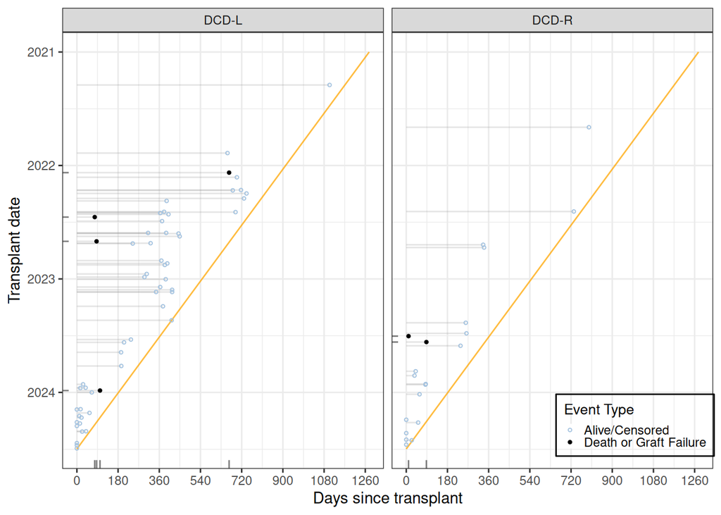

```r
days_observed =
  tibble(
    TX_DATE = seq(as.Date("2021-01-01"), as.Date("2024-07-01"), by = "1 day"),
    days = difftime(as.Date("2024-07-01"), TX_DATE, units = "days") %>%
      as.numeric()
  )

event_labels = c("Alive/Censored", "Death or Graft Failure")

post_tx %>%
  transmute(
    AGE_AT_TX,
    STATUS_AT_TX,
    TX_YEAR,
    TX_DATE,
    DCD_DON, # = case_match(DCD_DON, "N" ~ 'DBD', "Y" ~ "DCD"),
    WL_DCD_SEQ,
    EV_TIME,
    EV_TYPE = factor(EV_TYPE), # = case_match(EV_TYPE, 1 ~ "Death or Graft Failure", 0 ~ "Censored"),
  ) %>%
  filter(
    WL_DCD_SEQ %in% c("Yes", "No -> Yes")
  ) %>%
  mutate(
    DCD_DON = case_match(DCD_DON, "N" ~ "DCD-L", "Y" ~ "DCD-R" )
  ) %>%
  ggplot(aes(x = 0, xend = EV_TIME, y = TX_DATE, yend = TX_DATE)) +
  facet_wrap(~DCD_DON) +
  geom_line(data = days_observed, aes(x = days, y = TX_DATE), color = "orange", alpha = .75, inherit.aes = FALSE) +
  geom_segment(alpha = .25, color = "grey60") +
  # plot censored events first so events show more clearly
  geom_point(data = . %>% filter(EV_TYPE == 0),
             aes(x = EV_TIME, color = EV_TYPE, shape = EV_TYPE),
             size = .8) +
  geom_point(data = . %>% filter(EV_TYPE == 1),
             aes(x = EV_TIME, color = EV_TYPE, shape = EV_TYPE),
             size = .8) +
  scale_shape_manual(values = c(1, 19), labels = event_labels) +
  scale_color_manual(values = c("#A3C2DF", "black"), labels = event_labels) +
  geom_rug(data = . %>% filter(EV_TYPE == 1), aes(x = EV_TIME), alpha = .50, length = unit(.02, "npc")) +
  scale_x_continuous(breaks = seq(0, 1500, by = 180)) +
  scale_y_continuous(
    trans = c("date", "reverse")
  ) +
  labs(
    x = "Days since transplant",
    y = "Transplant date",
    color = "Event Type",
    shape = "Event Type"
  ) +
   theme(
     legend.position = "inside",
     legend.position.inside = c(.88, 1-.90),
     legend.key.size = unit(0.3, "cm"),
     legend.background = element_rect(color = "black", fill = "transparent"),
     legend.title = element_text(size = 10)
   )
```

## 3.8 Recipient Comparison

Comparison of values between DCD and DBD for **recipient** variables. Note: for here and below, we used *Fisher Exact Test* for comparing categorical variables and *Mann-Whitney U Test* for numeric variables.

```r
recipients =
  post_tx %>%
  left_join(
    read_rds(file.path(dir_data, "data_candidate.rds")),
    by = "WL_ID_CODE"
  ) %>%
  transmute(
    #PT_CODE, WL_ID_CODE, TRR_ID_CODE,
    DCD_DON = case_match(DCD_DON, "N" ~ "DBD", "Y" ~ "DCD") %>% factor(),
    #
    STATUS_AT_TX,
    PREV_TX,
    # NUM_PREV_TX,
    # PREV_TX_ANY_ORGAN,
    # DAYS_SINCE_PREV_TX,
    AGE_AT_TX,
    WEIGHT_CAND_KG,
    HEIGHT_CAND_CM,
    BMI_CAND,
    BSA_CAND,
    PHM_CAND,
    GENDER_CAND,
    RACE_CAND,
    ABO_CAND,
    PAYMENT_CAND,
    TBILI_CAND_TX,
    # MALIG_CAND_TX,
    # HEMO_PA_MN_CAND_TX,
    ALBUM_CAND_REG,
    MED_COND_CAND_TX,
    CREAT_CAND_TX,
    eGFR_CAND_TX,
    # PRIOR_CARD_SURG_CAND_REG,
    STEROID_CAND,
    # LIFE_SUPPORT_CAND_REG,
    LIFE_SUPPORT_CAND_TX,
    # ECMO_CAND_REG,
    ECMO_CAND_TX,
    # VAD_CAND_REG,
    VAD_CAND_TX,
    # VENTILATOR_CAND_REG,
    VENTILATOR_CAND_TX,
    VENT_SUPPORT_TX,
    FUNC_STAT_CAND_TX = case_match(FUNC_STAT_CAND_TX, NA ~ "Unknown", .default = FUNC_STAT_CAND_TX),
    # FUNC_STAT_CAND_REG,
    COGNITIVE_DEV_TRR,
    TRANSFUSIONS_CAND,
    INHALED_NO_CAND,
    INFECTION_CAND,
    HBV_ANTIGEN_CAND,
    # CMV_CAND,
    DIAL_CAND,
    A1_ANTIGEN_CAND,
    A2_ANTIGEN_CAND,
    B1_ANTIGEN_CAND,
    DR1_ANTIGEN_CAND,
    DR2_ANTIGEN_CAND,
    CAND_DIAG,
    # CAND_DIAG_CODE,
    # CAND_DIAG_full,
    # CAND_DIAG_primary,
    CPRA,
    CPRA_PEAK,
    HLAMIS,
    #: Time on Waitlist
    # DAYS_STAT1A,
    # DAYS_STAT1B,
    # DAYS_STAT2,
    DAYS_ACTIVE,
  )
```

```r
stat_test <- function(data, var, group = DCD_DON){
  x = data %>% pull({{group}})
  y = data %>% pull({{var}})
  var_name = data %>% select(any_of({{var}})) %>% colnames()

  # Mann–Whitney U / Wilcoxon–Mann–Whitney test
  if(is.numeric(y))
    test = wilcox.test(y~x)
  # Fisher's Exact Test
  else if(nlevels(factor(y)) < 10) test = fisher.test(table(x,y))
  else test = fisher.test(table(x,y), simulate.p.value = 1000)

  out = tibble(var = var_name, p_value = test$p.value, test = test$method)
  return(out)
}
```

Here’s a comparison of the most significant differences. Because of multiple testing, the evidence isn’t strong that there are any true differences.

```r
candidate_vars_compare =
  map_df(
    recipients %>% select(-DCD_DON) %>% colnames(),
    \(x) stat_test(recipients, x)
  )
```

```r
candidate_vars_compare %>% arrange(p_value)
```

| var | p_value | test |
| --- | --- | --- |
| LIFE_SUPPORT_CAND_TX | 0.0126493 | Fisher’s Exact Test for Count Data |
| DIAL_CAND | 0.0147223 | Fisher’s Exact Test for Count Data |
| VAD_CAND_TX | 0.0229071 | Fisher’s Exact Test for Count Data |
| MED_COND_CAND_TX | 0.0230905 | Fisher’s Exact Test for Count Data |
| VENT_SUPPORT_TX | 0.0273927 | Fisher’s Exact Test for Count Data |
| HEIGHT_CAND_CM | 0.0295488 | Wilcoxon rank sum test with continuity correction |
| BSA_CAND | 0.0303354 | Wilcoxon rank sum test with continuity correction |
| INFECTION_CAND | 0.0334249 | Fisher’s Exact Test for Count Data |
| WEIGHT_CAND_KG | 0.0368896 | Wilcoxon rank sum test with continuity correction |
| TRANSFUSIONS_CAND | 0.0385661 | Fisher’s Exact Test for Count Data |
| PHM_CAND | 0.0462786 | Wilcoxon rank sum test with continuity correction |
| STEROID_CAND | 0.0546573 | Fisher’s Exact Test for Count Data |
| VENTILATOR_CAND_TX | 0.0640536 | Fisher’s Exact Test for Count Data |
| HLAMIS | 0.0660227 | Wilcoxon rank sum test with continuity correction |
| PAYMENT_CAND | 0.0696157 | Fisher’s Exact Test for Count Data |
| eGFR_CAND_TX | 0.0725014 | Wilcoxon rank sum test with continuity correction |
| FUNC_STAT_CAND_TX | 0.0784608 | Fisher’s Exact Test for Count Data with simulated p-value |
| (based on 2000 replicates) |  |  |
| AGE_AT_TX | 0.0967154 | Wilcoxon rank sum test with continuity correction |
| COGNITIVE_DEV_TRR | 0.1037997 | Wilcoxon rank sum test with continuity correction |
| STATUS_AT_TX | 0.1129684 | Fisher’s Exact Test for Count Data |
| DAYS_ACTIVE | 0.1276421 | Wilcoxon rank sum test with continuity correction |
| BMI_CAND | 0.1310420 | Wilcoxon rank sum test with continuity correction |
| PREV_TX | 0.1489999 | Fisher’s Exact Test for Count Data |
| CAND_DIAG | 0.1845201 | Fisher’s Exact Test for Count Data |
| ALBUM_CAND_REG | 0.2457909 | Wilcoxon rank sum test with continuity correction |
| DR2_ANTIGEN_CAND | 0.3220742 | Wilcoxon rank sum test with continuity correction |
| HBV_ANTIGEN_CAND | 0.3417587 | Fisher’s Exact Test for Count Data |
| INHALED_NO_CAND | 0.3571535 | Wilcoxon rank sum test with continuity correction |
| TBILI_CAND_TX | 0.4389290 | Wilcoxon rank sum test with continuity correction |
| RACE_CAND | 0.4916258 | Fisher’s Exact Test for Count Data |
| GENDER_CAND | 0.5045184 | Fisher’s Exact Test for Count Data |
| CPRA_PEAK | 0.5292278 | Wilcoxon rank sum test with continuity correction |
| CREAT_CAND_TX | 0.5885961 | Wilcoxon rank sum test with continuity correction |
| A2_ANTIGEN_CAND | 0.6221137 | Wilcoxon rank sum test with continuity correction |
| DR1_ANTIGEN_CAND | 0.6385456 | Wilcoxon rank sum test with continuity correction |
| ABO_CAND | 0.7692028 | Fisher’s Exact Test for Count Data |
| A1_ANTIGEN_CAND | 0.8956013 | Wilcoxon rank sum test with continuity correction |
| CPRA | 0.9425966 | Wilcoxon rank sum test with continuity correction |
| B1_ANTIGEN_CAND | 0.9706546 | Wilcoxon rank sum test with continuity correction |
| ECMO_CAND_TX | 1.0000000 | Fisher’s Exact Test for Count Data |

### 3.8.1 Detailed Comparisons

```r
details_cat <- function(data, var, group = DCD_DON){
  data %>%
    count({{group}}, {{var}}) %>%
    mutate(.by = {{group}}, p = n / sum(n)) %>%
    mutate(
      stat = glue::glue("{n} ({round(p, 3) %>% str_pad(width = 5, side = 'right', pad = 0)})")
    ) %>%
    select(-n, -p) %>%
    spread({{group}}, stat) %>%
    gt()
}
```

| LIFE_SUPPORT_CAND_TX | DBD | DCD |
| --- | --- | --- |
| No | 447 (0.294) | 3 (0.150) |
| Unknown | 71 (0.047) | 4 (0.200) |
| Yes | 1002 (0.659) | 13 (0.650) |

| DIAL_CAND | DBD | DCD |
| --- | --- | --- |
| No | 1408 (0.926) | 15 (0.750) |
| Unknown | 75 (0.049) | 4 (0.200) |
| Yes | 37 (0.024) | 1 (0.050) |

| VAD_CAND_TX | DBD | DCD |
| --- | --- | --- |
| No | 865 (0.569) | 8 (0.400) |
| Unknown | 75 (0.049) | 4 (0.200) |
| Yes | 580 (0.382) | 8 (0.400) |

| MED_COND_CAND_TX | DBD | DCD |
| --- | --- | --- |
| Hospital_No_ICU | 510 (0.336) | 3 (0.150) |
| ICU | 648 (0.426) | 9 (0.450) |
| Not_in_hospital | 290 (0.191) | 4 (0.200) |
| Unknown | 72 (0.047) | 4 (0.200) |

| VENT_SUPPORT_TX | DBD | DCD |
| --- | --- | --- |
| No | 908 (0.597) | 8 (0.400) |
| Unknown | 92 (0.061) | 4 (0.200) |
| Yes | 520 (0.342) | 8 (0.400) |

```r
details_num <- function(data, var, group = DCD_DON){
  data %>%
  summarize(
    .by = {{group}},
    n = sum(!is.na({{var}})),
    Q1 = quantile({{var}}, probs = .25, na.rm=TRUE),
    median = median({{var}}, na.rm=TRUE),
    Q3 = quantile({{var}}, probs = .75, na.rm=TRUE),
    IQR = glue::glue("({round(Q1)}, {round(Q3)})"),
    stat = glue::glue("{round(median)} ({round(Q1)}, {round(Q3)})")
  ) %>%
  select(
    DONOR_TYPE = {{group}}, n, median, IQR, stat
  ) %>%
  gt() %>%
  tab_header(title = enquo(var)) # warning message. use as_label() or as_name()
}
```

```r
recipients %>% details_num(HEIGHT_CAND_CM)
```

~ HEIGHT_CAND_CM

| DONOR_TYPE | n | median | IQR | stat |
| --- | --- | --- | --- | --- |
| DBD | 1520 | 127 | (76, 159) | 127 (76, 159) |
| DCD | 20 | 101 | (59, 143) | 101 (59, 143) |

```r
recipients %>% details_num(BSA_CAND)
```

~ BSA_CAND

| DONOR_TYPE | n | median | IQR | stat |
| --- | --- | --- | --- | --- |
| DBD | 1520 | 0.9951995 | (0, 2) | 1 (0, 2) |
| DCD | 20 | 0.6631580 | (0, 1) | 1 (0, 1) |

```r
recipients %>% details_num(WEIGHT_CAND_KG)
```

~ WEIGHT_CAND_KG

| DONOR_TYPE | n | median | IQR | stat |
| --- | --- | --- | --- | --- |
| DBD | 1520 | 27.7 | (10, 53) | 28 (10, 53) |
| DCD | 20 | 15.7 | (5, 42) | 16 (5, 42) |

## 3.9 Offer Comparison

Comparison of values between DCD and DBD for **offer** variables.

```r
tmp =
  post_tx %>%
  # left_join(
  #   read_rds(file.path(dir_data, "data_candidate.rds")),
  #   by = "WL_ID_CODE"
  # ) %>%
  transmute(
    DCD_DON = case_match(DCD_DON, "N" ~ "DBD", "Y" ~ "DCD") %>% factor(),
    TX_YEAR,
    ISCHTIME,
    DISTANCE,
  )
```

```r
  map_df(
    tmp %>% select(-DCD_DON) %>% colnames(),
    \(x) stat_test(tmp, x)
  ) %>%
  arrange(p_value)
```

| var | p_value | test |
| --- | --- | --- |
| DISTANCE | 0.0008491 | Wilcoxon rank sum test with continuity correction |
| TX_YEAR | 0.0024864 | Wilcoxon rank sum test with continuity correction |
| ISCHTIME | 0.7388151 | Wilcoxon rank sum test with continuity correction |

### 3.9.1 Detailed Comparison

```r
tmp %>% details_cat(TX_YEAR)
```

| TRANSPLANT YEAR | DBD | DCD |
| --- | --- | --- |
| 2021 | 328 (0.216) | 1 (0.050) |
| 2022 | 462 (0.304) | 3 (0.150) |
| 2023 | 489 (0.322) | 9 (0.450) |
| 2024 | 241 (0.159) | 7 (0.350) |

```r
tmp %>% details_num(DISTANCE)
```

~ DISTANCE

| DONOR_TYPE | n | median | IQR | stat |
| --- | --- | --- | --- | --- |
| DBD | 1520 | 290.5 | (157, 411) | 290 (157, 411) |
| DCD | 20 | 477.0 | (292, 592) | 477 (292, 592) |

## 3.10 Donor-Candidate Matching Comparison

Comparison of values between DCD and DBD for **donor-candidate comparison** variables.

```r
tmp =
  post_tx %>%
  left_join(
    read_rds(file.path(dir_data, "data_donor_candidate.rds")),
    by = "WL_ID_CODE"
  ) %>%
  transmute(
    DCD_DON = case_match(DCD_DON, "N" ~ "DBD", "Y" ~ "DCD") %>% factor(),
    ABO_STR,
    ABO_MATCH,
    RACE_STR,
    RACE_MATCH,
    GENDER_STR,
    GENDER_MATCH,
    WEIGHT_RATIO,
    WEIGHT_DIFF,
    HEIGHT_RATIO,
    HEIGHT_DIFF,
    BMI_RATIO,
    BMI_DIFF,
    AGE_DIFF,
    BSA_RATIO,
    BSA_DIFF,
    PHM_RATIO,
    PHM_DIFF
  )
```

```r
map_df(
  tmp %>% select(-DCD_DON) %>% colnames(),
  \(x) stat_test(tmp, x)
) %>%
arrange(p_value)
```

| var | p_value | test |
| --- | --- | --- |
| GENDER_MATCH | 0.0248117 | Wilcoxon rank sum test with continuity correction |
| ABO_MATCH | 0.0427201 | Wilcoxon rank sum test with continuity correction |
| GENDER_STR | 0.1652058 | Fisher’s Exact Test for Count Data |
| ABO_STR | 0.1799100 | Fisher’s Exact Test for Count Data with simulated p-value |
| (based on 2000 replicates) |  |  |
| HEIGHT_RATIO | 0.3132898 | Wilcoxon rank sum test with continuity correction |
| BSA_RATIO | 0.3219280 | Wilcoxon rank sum test with continuity correction |
| WEIGHT_RATIO | 0.4378192 | Wilcoxon rank sum test with continuity correction |
| PHM_RATIO | 0.4543019 | Wilcoxon rank sum test with continuity correction |
| RACE_MATCH | 0.4768902 | Wilcoxon rank sum test with continuity correction |
| RACE_STR | 0.4832584 | Fisher’s Exact Test for Count Data with simulated p-value |
| (based on 2000 replicates) |  |  |
| HEIGHT_DIFF | 0.5714103 | Wilcoxon rank sum test with continuity correction |
| BSA_DIFF | 0.7067050 | Wilcoxon rank sum test with continuity correction |
| BMI_DIFF | 0.7241086 | Wilcoxon rank sum test with continuity correction |
| BMI_RATIO | 0.7697774 | Wilcoxon rank sum test with continuity correction |
| PHM_DIFF | 0.9013881 | Wilcoxon rank sum test with continuity correction |
| AGE_DIFF | 0.9857776 | Wilcoxon rank sum test with continuity correction |
| WEIGHT_DIFF | 0.9971714 | Wilcoxon rank sum test with continuity correction |

### 3.10.1 Detailed Comparison

```r
tmp %>% details_cat(GENDER_MATCH)
```

| GENDER_MATCH | DBD | DCD |
| --- | --- | --- |
| 0 | 686 (0.451) | 4 (0.200) |
| 1 | 834 (0.549) | 16 (0.800) |

```r
tmp %>% details_cat(ABO_MATCH)
```

| ABO_MATCH | DBD | DCD |
| --- | --- | --- |
| 1 | 1078 (0.709) | 10 (0.500) |
| 2 | 313 (0.206) | 7 (0.350) |
| 3 | 129 (0.085) | 3 (0.150) |

```r
tmp %>% details_cat(GENDER_STR)
```

| GENDER_STR | DBD | DCD |
| --- | --- | --- |
| F\|F | 267 (0.176) | 5 (0.250) |
| F\|M | 296 (0.195) | 2 (0.100) |
| M\|F | 390 (0.257) | 2 (0.100) |
| M\|M | 567 (0.373) | 11 (0.550) |

## 3.11 Donor Comparisons

Comparison of values between DCD and DBD for **donor** variables.

```r
tmp =
  post_tx %>%
  left_join(
    read_rds(file.path(dir_data, "data_donor.rds")),
    by = "WL_ID_CODE"
  ) %>%
  transmute(
    DCD_DON = case_match(DCD_DON, "N" ~ "DBD", "Y" ~ "DCD") %>% factor(),
    AGE_DON,
    GENDER_DON,
    RACE_DON,
    WEIGHT_DON_KG,
    HEIGHT_DON_CM,
    BSA_DON,
    BMI_DON,
    PHM_DON,
    ABO_DON,
    CPR_ADMIN_DON,
    CPR_DURATION_DON,
    CARDARREST_DON,
    CARDARREST_DURATION_DON,
    CARDARREST_POSTNEURO_DON,
    RESUSCIT_DON,
    RESUSCIT_DURATION_DON,
    COD_DON,
    DEATH_CIRCUM_DON,
    DEATH_MECH_DON,
    CHEST_TRAUMA_DON,
    RISK_HIV_DON,
    RISK_OTHER_DON,
    RISK_DRUGS_DON,
    RISK_HEP_DON,
    PCO2_DON,
    PO2_FIO2_DON,
    PO2_DON,
    SGOT_DON,
    SGPT_DON,
    CMV_DON,
    TRANSFUS_TERM_DON,
    HEMATOCRIT_DON,
    INOTROP_SUPPORT_DON,
    TBILI_DON,
    BUN_DON,
    CLIN_INFECT_DON,
    BLOOD_INF_DON,
    PULM_INF_DON,
    URINE_INF_DON,
    OTHER_INF_DON,
    A1_ANTIGEN_DON,
    B1_ANTIGEN_DON,
    ARGININE_DON,
    CREAT_DON,
    eGFR_DON,
    # ABN_CONGEN_DON,
    # ABN_LVH_DON,
    # ABN_VALVES_DON,
    EBV_IGG_CAD_DON,
    EBV_IGM_CAD_DON,
    # WALL_ABN_GLOB_DON,
    # WALL_ABN_SEG_DON,
    LV_EJECT_DON,
    # LV_EJECT_METH_DON,
    # SHFRAC,
    # POSTERIOR_WALL,
    SEPTAL_WALL,
    # ECHO_ABNL_CUM,
    # ECHO_LVSWMA,
    # ECHO_OBJECTIVE,
    # ECHO_OBJECTIVE_SCALE,
    # ECHO_VALVE_FXN,
    # ECHO_QUAL,
    # ECHO_GLOBAL_VENT_DYSF,
    # ECHO_biplane_eject_frac,
    # ECHO_qual_eject_frac,
    # ECHO_four_chamber_eject_frac
  )
```

```r
map_df(
  tmp %>% select(-DCD_DON) %>% colnames(),
  \(x) stat_test(tmp, x)
) %>%
arrange(p_value)
```

| var | p_value | test |
| --- | --- | --- |
| CARDARREST_POSTNEURO_DON | 0.0000000 | Fisher’s Exact Test for Count Data |
| ARGININE_DON | 0.0000006 | Fisher’s Exact Test for Count Data |
| LV_EJECT_DON | 0.0073108 | Wilcoxon rank sum test with continuity correction |
| INOTROP_SUPPORT_DON | 0.0091965 | Fisher’s Exact Test for Count Data |
| RISK_HIV_DON | 0.0178932 | Fisher’s Exact Test for Count Data |
| RISK_DRUGS_DON | 0.0313887 | Fisher’s Exact Test for Count Data |
| RISK_OTHER_DON | 0.0346429 | Fisher’s Exact Test for Count Data |
| BSA_DON | 0.0429876 | Wilcoxon rank sum test with continuity correction |
| PO2_DON | 0.0476260 | Wilcoxon rank sum test with continuity correction |
| WEIGHT_DON_KG | 0.0515273 | Wilcoxon rank sum test with continuity correction |
| TBILI_DON | 0.0572234 | Wilcoxon rank sum test with continuity correction |
| HEIGHT_DON_CM | 0.0582486 | Wilcoxon rank sum test with continuity correction |
| CREAT_DON | 0.0626232 | Wilcoxon rank sum test with continuity correction |
| TRANSFUS_TERM_DON | 0.0658471 | Wilcoxon rank sum test with continuity correction |
| PHM_DON | 0.0663476 | Wilcoxon rank sum test with continuity correction |
| PO2_FIO2_DON | 0.0868600 | Wilcoxon rank sum test with continuity correction |
| OTHER_INF_DON | 0.1094766 | Wilcoxon rank sum test with continuity correction |
| A1_ANTIGEN_DON | 0.1208051 | Wilcoxon rank sum test with continuity correction |
| BUN_DON | 0.1282234 | Wilcoxon rank sum test with continuity correction |
| BMI_DON | 0.1376457 | Wilcoxon rank sum test with continuity correction |
| AGE_DON | 0.1600675 | Wilcoxon rank sum test with continuity correction |
| eGFR_DON | 0.1951115 | Wilcoxon rank sum test with continuity correction |
| SGPT_DON | 0.2291027 | Wilcoxon rank sum test with continuity correction |
| URINE_INF_DON | 0.2498509 | Wilcoxon rank sum test with continuity correction |
| PCO2_DON | 0.2932889 | Wilcoxon rank sum test with continuity correction |
| DEATH_MECH_DON | 0.3028486 | Fisher’s Exact Test for Count Data with simulated p-value |
| (based on 2000 replicates) |  |  |
| COD_DON | 0.3440715 | Fisher’s Exact Test for Count Data |
| CPR_ADMIN_DON | 0.3603547 | Fisher’s Exact Test for Count Data |
| HEMATOCRIT_DON | 0.3615540 | Wilcoxon rank sum test with continuity correction |
| RESUSCIT_DURATION_DON | 0.3654293 | Wilcoxon rank sum test with continuity correction |
| CLIN_INFECT_DON | 0.3755992 | Fisher’s Exact Test for Count Data |
| ABO_DON | 0.4538132 | Fisher’s Exact Test for Count Data |
| CARDARREST_DON | 0.4667002 | Fisher’s Exact Test for Count Data |
| CARDARREST_DURATION_DON | 0.5046461 | Wilcoxon rank sum test with continuity correction |
| RACE_DON | 0.5073507 | Fisher’s Exact Test for Count Data |
| CHEST_TRAUMA_DON | 0.6078670 | Fisher’s Exact Test for Count Data |
| CPR_DURATION_DON | 0.6619279 | Wilcoxon rank sum test with continuity correction |
| EBV_IGG_CAD_DON | 0.6792588 | Fisher’s Exact Test for Count Data |
| SEPTAL_WALL | 0.6846756 | Wilcoxon rank sum test with continuity correction |
| EBV_IGM_CAD_DON | 0.7102295 | Fisher’s Exact Test for Count Data |
| RISK_HEP_DON | 0.7105840 | Fisher’s Exact Test for Count Data |
| DEATH_CIRCUM_DON | 0.7449188 | Fisher’s Exact Test for Count Data |
| SGOT_DON | 0.8654286 | Wilcoxon rank sum test with continuity correction |
| PULM_INF_DON | 0.8721868 | Wilcoxon rank sum test with continuity correction |
| B1_ANTIGEN_DON | 0.9454052 | Wilcoxon rank sum test with continuity correction |
| GENDER_DON | 1.0000000 | Fisher’s Exact Test for Count Data |
| RESUSCIT_DON | 1.0000000 | Fisher’s Exact Test for Count Data |
| CMV_DON | 1.0000000 | Fisher’s Exact Test for Count Data |
| BLOOD_INF_DON | 1.0000000 | Wilcoxon rank sum test with continuity correction |

### 3.11.1 Detailed Comparisons

```r
tmp %>% details_cat(CARDARREST_POSTNEURO_DON)
```

| CARDARREST_POSTNEURO_DON | DBD | DCD |
| --- | --- | --- |
| No | 1386 (0.912) | NA |
| Unknown | 47 (0.031) | 20 (10000) |
| Yes | 87 (0.057) | NA |

```r
tmp %>% details_cat(ARGININE_DON)
```

| ARGININE_DON | DBD | DCD |
| --- | --- | --- |
| No | 321 (0.211) | 14 (0.700) |
| Unknown | 47 (0.031) | 2 (0.100) |
| Yes | 1152 (0.758) | 4 (0.200) |

```r
tmp %>% details_num(LV_EJECT_DON)
```

~ LV_EJECT_DON

| DONOR_TYPE | n | median | IQR | stat |
| --- | --- | --- | --- | --- |
| DBD | 1497 | 64 | (60, 69) | 64 (60, 69) |
| DCD | 19 | 69 | (64, 70) | 69 (64, 70) |

```r
tmp %>% details_cat(INOTROP_SUPPORT_DON)
```

| INOTROP_SUPPORT_DON | DBD | DCD |
| --- | --- | --- |
| No | 997 (0.656) | 17 (0.850) |
| Unknown | 49 (0.032) | 2 (0.100) |
| Yes | 474 (0.312) | 1 (0.050) |

```r
tmp %>% details_cat(RISK_HIV_DON)
```

| RISK_HIV_DON | DBD | DCD |
| --- | --- | --- |
| No | 1438 (0.946) | 18 (0.900) |
| Unknown | 13 (0.009) | 2 (0.100) |
| Yes | 69 (0.045) | NA |

```r
tmp %>% details_cat(RISK_DRUGS_DON)
```

| RISK_DRUGS_DON | DBD | DCD |
| --- | --- | --- |
| No | 793 (0.522) | 8 (0.400) |
| Unknown | 432 (0.284) | 11 (0.550) |
| Yes | 295 (0.194) | 1 (0.050) |

```r
tmp %>% details_cat(RISK_OTHER_DON)
```

| RISK_OTHER_DON | DBD | DCD |
| --- | --- | --- |
| No | 803 (0.528) | 8 (0.400) |
| Unknown | 433 (0.285) | 11 (0.550) |
| Yes | 284 (0.187) | 1 (0.050) |

## 3.12 Waitlist and Offer Comparison

Comparison of values between DCD and DBD for **waitlist** variables.

Note that this only compares the waitlist data for transplants. The `DAYS_ON_WL` isn’t a proper comparison between groups due to censoring, waitlist deterioration, change in status, etc. A better comparison is found in Section 4.

```r
tmp =
  post_tx %>%
  left_join(
    read_rds(file.path(dir_data, "data_ptr.rds")),
    by = "WL_ID_CODE"
  ) %>%
  transmute(
    DCD_DON = case_match(DCD_DON, "N" ~ "DBD", "Y" ~ "DCD") %>% factor(),
    n_refusals,  # number of donor refusals before acceptance
    PTR_SEQ_NUM_AT_ACCEPT = PTR_AT_ACCEPT, # times donor had been offered before acceptance
    STATUS_AT_TX,     # 1A, 1B, 2
    DAYS_ON_WL   # total days on waitlist (including inactive)
  )
```

```r
map_df(
  tmp %>% select(-DCD_DON) %>% colnames(),
  \(x) stat_test(tmp, x)
) %>%
arrange(p_value)
```

| var | p_value | test |
| --- | --- | --- |
| DAYS_ON_WL | 0.0979129 | Wilcoxon rank sum test with continuity correction |
| STATUS_AT_TX | 0.1129684 | Fisher’s Exact Test for Count Data |
| PTR_SEQ_NUM_AT_ACCEPT | 0.3090032 | Wilcoxon rank sum test with continuity correction |
| n_refusals | 0.8927692 | Wilcoxon rank sum test with continuity correction |

### 3.12.1 Detailed Comparison

```r
tmp %>% details_num(DAYS_ON_WL)
```

~ DAYS_ON_WL

| DONOR_TYPE | n | median | IQR | stat |
| --- | --- | --- | --- | --- |
| DBD | 1520 | 81.0 | (24, 162) | 81 (24, 162) |
| DCD | 20 | 39.5 | (10, 94) | 40 (10, 94) |

```r
tmp %>% details_cat(STATUS_AT_TX)
```

| STATUS_AT_TX | DBD | DCD |
| --- | --- | --- |
| HR: Status 1A | 1283 (0.844) | 14 (0.700) |
| HR: Status 1B | 208 (0.137) | 5 (0.250) |
| HR: Status 2 | 29 (0.019) | 1 (0.050) |

```r
tmp %>% details_num(n_refusals)
```

~ n_refusals

| DONOR_TYPE | n | median | IQR | stat |
| --- | --- | --- | --- | --- |
| DBD | 1519 | 5 | (2, 12) | 5 (2, 12) |
| DCD | 20 | 4 | (3, 12) | 4 (3, 12) |

# 4 Waitlist Outcomes

There are many challenges in trying to understand changes in waitlist time. The main difficulty is that this is a *competing risks* problem, not survival, because there are many reasons to be removed from the waitlist (e.g., dead, improvement, removed in error, listed at two centers). One of the other studies compared median waitimes for transplanted patients; this is misleading because sicker patients may not make it to transplant and aren’t included in the analysis. This issue makes it difficult to estimate median time to transplant.

The other issues are that candidates change status, change DCD acceptability, and refuse (good) offers. Plus the usual issues impacting wait time: size, ABO, Listing Center (or geographic location which impacts number of donors within distance bands).

I’m still trying to work out a good method to assess waiting times. In the mean time here are some other metrics related to waitlist outcomes.

## 4.1 Outcome Rates

This looks at the waitlist outcomes for each type of DCD Listed Candidate.

Waitlist outcomes:

- **Success**: “Deceased Donor tx, removed by tx center”, “Cand. condition improved, tx not needed”, “Tx at another center (multiple-listing)”.
- **Adverse**: “Died”, “Cand. cond. deteriorated,too sick to tx”
- **Other**: all other reasons for waitlist removal like “Transferred to another center”, “Refused transplant”, “Unable to contact candidate”, “Candidate Removed in Error”
- **Still on waitlist**: candidate is still on waitlist at time of data collection

```r
outcome_counts =
  patients %>%
  left_join(WL_DCD, by = "WL_ID_CODE") %>%
  #filter(WL_DCD_SEQ %in% c("Yes", "Yes -> No")) %>%
  select(
    WL_ID_CODE,
    STATUS_AT_LISTING,
    WL_INIT_DATE,
    WL_REMOVAL_REASON,
    WL_END_DATE,
    DAYS_ON_WL,
    TXED,
    STATUS_AT_LISTING,
    AGE_AT_LISTING,
    WL_DCD_SEQ
  ) %>%
  mutate(
    WL_OUTCOME = case_match(WL_REMOVAL_REASON,
                            "Deceased Donor tx, removed by tx center" ~ "Success",
                            "Cand. condition improved, tx not needed" ~ "Success",
                            "Tx at another center (multiple-listing)" ~ "Success",
                            "Died" ~ "Adverse",
                            "Cand. cond. deteriorated,too sick to tx" ~ "Adverse",
                            "Still on waitlist" ~ "Still on waitlist",
                            .default = "Other"
    )
  ) %>%
  count(WL_DCD_SEQ, WL_OUTCOME) %>%
  complete(WL_DCD_SEQ, WL_OUTCOME, fill = list(n = 0L))
```

```r
outcome_counts %>%
  mutate(.by = WL_DCD_SEQ, p = n / sum(n)) %>%
  mutate(
    p = scales::percent(p, accuracy = .1),
    stat = glue::glue("{n} ({p})")
  ) %>%
  transmute(
    DCD_Listing = factor(WL_DCD_SEQ, c("No", "Yes", "Yes -> No", "No -> Yes")),
    WL_OUTCOME = factor(WL_OUTCOME, c("Success", "Adverse", "Other", "Still on waitlist")),
    stat
  ) %>%
  pivot_wider(names_from = WL_OUTCOME, values_from = stat) %>%
  arrange(DCD_Listing) %>%
  select(DCD_Listing, Success, Adverse, Other, `Still on waitlist`) %>%
  gt()
```

| DCD_Listing | Success | Adverse | Other | Still on waitlist |
| --- | --- | --- | --- | --- |
| No | 1593 (67.7%) | 227 (9.6%) | 96 (4.1%) | 437 (18.6%) |
| Yes | 47 (66.2%) | 11 (15.5%) | 2 (2.8%) | 11 (15.5%) |
| Yes -> No | 12 (80.0%) | 2 (13.3%) | 0 (0.0%) | 1 (6.7%) |
| No -> Yes | 33 (70.2%) | 2 (4.3%) | 1 (2.1%) | 11 (23.4%) |

We can add confidence intervals or standard errors, etc. A statistical test on equal distributions (chi-sq or Fisher Exact) accepts the null hypotheses that there is not enough evidence to suggest differences in outcomes.

```r
outcome_counts %>%
  pivot_wider(names_from = "WL_OUTCOME", values_from = "n", values_fill = 0L) %>%
  select(-WL_DCD_SEQ) %>%
  as.matrix() %>%
  chisq.test(simulate.p.value = TRUE, B = 8000)
```

```
    Pearson's Chi-squared test with simulated p-value (based on 8000
    replicates)

data:  .
X-squared = 7.8873, df = NA, p-value = 0.5273
```

```r
  # fisher.test(simulate.p.value = TRUE, B = 8000)
```

### 4.1.1 Removing “Still on waitlist”

```r
outcome_counts %>%
  filter(WL_OUTCOME != "Still on waitlist") %>%
  mutate(.by = WL_DCD_SEQ, p = n / sum(n)) %>%
  mutate(
    p = scales::percent(p, accuracy = .1),
    stat = glue::glue("{n} ({p})")
  ) %>%
  transmute(
    DCD_Listing = factor(WL_DCD_SEQ, c("No", "Yes", "Yes -> No", "No -> Yes")),
    WL_OUTCOME = factor(WL_OUTCOME, c("Success", "Adverse", "Other", "Still on waitlist")),
    stat
  ) %>%
  pivot_wider(names_from = WL_OUTCOME, values_from = stat) %>%
  arrange(DCD_Listing) %>%
  select(DCD_Listing, Success, Adverse, Other) %>%
  gt()
```

| DCD_Listing | Success | Adverse | Other |
| --- | --- | --- | --- |
| No | 1593 (83.1%) | 227 (11.8%) | 96 (5.0%) |
| Yes | 47 (78.3%) | 11 (18.3%) | 2 (3.3%) |
| Yes -> No | 12 (85.7%) | 2 (14.3%) | 0 (0.0%) |
| No -> Yes | 33 (91.7%) | 2 (5.6%) | 1 (2.8%) |

### 4.1.2 Table for ISHLT Abstract

Notes:

- This doesn’t account for important differences like Status (e.g., higher percentage of DCD-L are 1A).

```r
outcome_counts %>%
  #filter(WL_OUTCOME != "Other") %>%
  mutate(
    WL_DCD_SEQ = case_match(WL_DCD_SEQ,
                            "No -> Yes" ~ "DCD", #"Yes and No -> Yes",
                            "Yes -> No" ~ "DBD",#"No and Yes -> No",
                            "Yes" ~ "DCD",#"Yes and No -> Yes",
                            "No" ~ "DBD") #"No and Yes -> No")
  ) %>%
  summarize(.by = c(WL_DCD_SEQ, WL_OUTCOME), n = sum(n)) %>%
  mutate(.by = WL_DCD_SEQ, p = n / sum(n)) %>%
  mutate(
    p = scales::percent(p, accuracy = .1),
    stat = glue::glue("{n} ({p})")
  ) %>%
  transmute(
    n,
    DCD_Listing = WL_DCD_SEQ,
    WL_OUTCOME = case_match(WL_OUTCOME, "Adverse" ~ "Death or deterioration",
                            "Still on waitlist" ~ "Alive on waitlist",
                            "Success" ~ "Transplant/Improved",
                            .default = WL_OUTCOME),
    #DCD_Listing = factor(WL_DCD_SEQ, c("Yes and No -> Yes", "No and Yes -> No")),
    #DCD_Listing = factor(WL_DCD_SEQ, c("DCD", "DBD")),
    # WL_OUTCOME = factor(WL_OUTCOME, c("Success", "Adverse", "Other", "Still on waitlist")),
    stat
  ) %>%
  mutate(
    .by = DCD_Listing,
    DCD_Listing = glue::glue("{DCD_Listing} n = {sum(n)}")
  ) %>%
  select(-n) %>%
  #pivot_wider(names_from = WL_OUTCOME, values_from = stat) %>%
  #arrange(DCD_Listing) %>%
  #select(DCD_Listing, Success, Adverse,  `Still on waitlist`) %>%
  pivot_wider(names_from = DCD_Listing, values_from = stat) %>%
  rename(Outcomes = WL_OUTCOME) %>%
  gt()
```

| Outcomes | DBD n = 2368 | DCD n = 118 |
| --- | --- | --- |
| Death or deterioration | 229 (9.7%) | 13 (11.0%) |
| Other | 96 (4.1%) | 3 (2.5%) |
| Alive on waitlist | 438 (18.5%) | 22 (18.6%) |
| Transplant/Improved | 1605 (67.8%) | 80 (67.8%) |

```r
tab =
  outcome_counts %>%
  #filter(WL_OUTCOME != "Other") %>%
  mutate(
    WL_DCD_SEQ = case_match(WL_DCD_SEQ,
                            "No -> Yes" ~ "DCD", #"Yes and No -> Yes",
                            "Yes -> No" ~ "DBD",#"No and Yes -> No",
                            "Yes" ~ "DCD",#"Yes and No -> Yes",
                            "No" ~ "DBD") #"No and Yes -> No")
  ) %>%
  summarize(
    .by = c(WL_DCD_SEQ, WL_OUTCOME),
    n = sum(n)
  ) %>%
  pivot_wider(names_from = WL_DCD_SEQ, values_from = n) %>%
  select(-WL_OUTCOME)
```

```r
print("Fisher's Test")
```

```
[1] "Fisher's Test"
```

```r
fisher.test(tab)
```

```
    Fisher's Exact Test for Count Data

data:  tab
p-value = 0.8729
alternative hypothesis: two.sided
```

```r
print("Chi-sq Test")
```

```
[1] "Chi-sq Test"
```

```r
chisq.test(tab)
```

```
    Pearson's Chi-squared test

data:  tab
X-squared = 0.8556, df = 3, p-value = 0.8361
```

## 4.2 “Good Offers”

A “good” offer is one from a donor that was eventually accepted by some candidate and the refusal code isn’t related to size mismatch. We can adjust this definition as necessary. See below for some basic statistics.

```r
# TODO: Refusal reason for DCD Donors vs. non-DCD Donors

good_offers =
  offers %>%
  mutate(
    DCD_DON = coalesce(DCD_DON, "N"), # replace unknown DCD with No
    REFUSAL_SIZE = PRIME_OPO_REFUSAL_ID %in% c(701, 831) | SECOND_OPO_REFUSAL_ID %in% c(701, 831),
    ACCEPT_EVER = !is.na(MAX_ACCEPT_SEQ),
    GOOD_OFFER = ACCEPT_EVER & !REFUSAL_SIZE,
  )
```

Using all offers to pediatric candidates (under 18 *at time of offer*). Note that our definition of “eventually accepted” has a small bias due to censoring for recent Match Runs.

```r
good_offers %>%
  filter(AGE_CAND < 18) %>%
  count(GOOD_OFFER, REFUSAL_SIZE, ACCEPT_EVER, DCD_DON) %>%
  summarize(
    .by = DCD_DON,
    n_offers = sum(n),
    `Pr(Good Offer)` = sum(n[GOOD_OFFER]) / sum(n),
    `Pr(Refusal due to size)` = sum(n[REFUSAL_SIZE]) / sum(n),
    `Pr(Donor eventually accepted)` = sum(n[ACCEPT_EVER]) / sum(n)
  )
```

| DCD_DON | n_offers | Pr(Good Offer) | Pr(Refusal due to size) | Pr(Donor eventually accepted) |
| --- | --- | --- | --- | --- |
| N | 24371 | 0.3806573 | 0.1372123 | 0.4693693 |
| Y | 531 | 0.2165725 | 0.0828625 | 0.2354049 |

## 4.3 Offer Rates and Time between offers

This section looks at the offer rates and time between offers. Note that we are not actually using the exact offer time, but time of the match run for the offer. Since centers have 30 mins to respond, the actual time of the offer is longer, especially for candidates far down on the match run list.  
We don’t have the exact offer time; we have the response time, but it is very noisy with many outliers.

```r
tmp =
bind_rows(
  WL =
    waitlists %>%
    select(
      WL_ID_CODE,
      CHG_DT,
      CHG_TY,
      STATUS,
      ACCEPT_DCD = DONCRIT_ACPT_DCD,
      #DONCRIT_ACPT_DCD_IMPORT,
      #PRELIM_XMATCH_REQ, contains("DONCRIT"), CPRA
    ) %>%
    # replace_na(list(DONCRIT_ACPT_ABO_INCOMP = "Unknown", DONCRIT_ACPT_DCD_IMPOR = "Unknown",
    #                 DONCRIT_GENDER_REQ = "Unknown", DONCRIT_ACPT_HIST_CAD = "Unknown")) %>%
    arrange(WL_ID_CODE, CHG_DT) %>%
    filter(
      .by = WL_ID_CODE,
      case_when(
        CHG_TY == "A" ~ TRUE,
        CHG_TY == "D" ~ TRUE,
        STATUS != lag(STATUS) ~ TRUE,
        ACCEPT_DCD != lag(ACCEPT_DCD) ~ TRUE,
        .default = FALSE
      )
    ) %>%
    # Remove initial "inactive" listings
    filter(
      !(STATUS == "Temporarily Inactive" & CHG_TY == "A")
    ) %>%
    arrange(CHG_DT) %>%
    mutate(
      .by = WL_ID_CODE,
      CHG_TY = ifelse(row_number() == 1 & CHG_TY == "M", "A", CHG_TY)
    ),

  OFFER =
    good_offers %>%
    transmute(
      WL_ID_CODE,
      CHG_DT = MATCH_SUBMIT_DT, #INITIAL_RESPONSE_DT, FINAL_RESPONSE_DT,
      CHG_TY = "Offer",
      AGE_CAND,
      DCD_DON,
      GOOD_OFFER,
      LISTING_CTR_CODE,
    ),

  .id = "type"
  ) %>%
  group_by(WL_ID_CODE) %>%
    arrange(CHG_DT) %>%
    fill(
      STATUS, ACCEPT_DCD, .direction = "down"
    ) %>%
  ungroup() %>%
  arrange(WL_ID_CODE, CHG_DT)
```

```r
#: Calculate time between two date-times (year, month, day, hour, minute, second)
#  Note: this function ignores timezones so be sure DT1 and DT2 have same tz.
library(lubridate)
calc_dur <- function(DT1, DT2, units = "days"){
  if(tz(DT1) != tz(DT2)) warning("DT1 does not have same timezone as DT2")
  int = lubridate::interval(DT1, DT2)
  lubridate::time_length(int, unit = units)
}
```

```r
# Some patients are always Inactive on the waitlist
inactive =
  waitlists %>%
  filter(
    .by = WL_ID_CODE,
    all(STATUS == "Temporarily Inactive")
  ) %>%
  distinct(WL_ID_CODE)
```

There are n = 5 waitlist patients that were always “Temporarily Inactive”.

```r
tmp2 =
  tmp %>%
  anti_join(inactive, by = "WL_ID_CODE") %>%
  arrange(WL_ID_CODE, CHG_DT) %>% # data must be ordered
  mutate(
    .by = WL_ID_CODE,
    #: calculate time at status
    dt = calc_dur(lag(CHG_DT), CHG_DT) %>% coalesce(0),
    dt_STATUS = lag(STATUS),        # status for calculation
    dt_ACCEPT_DCD = lag(ACCEPT_DCD) # dcd accept flag for calculation
  ) %>%
  filter(!is.na(dt_STATUS)) %>%  # remove rows with no information
  summarize(
    .by = c(WL_ID_CODE, dt_ACCEPT_DCD, dt_STATUS),
    days = sum(dt),
    n_offers = sum(type == "OFFER"),
    n_good_offers = sum(type == "OFFER" & GOOD_OFFER),
    n_dcd_offers = sum(type == "OFFER" & DCD_DON == "Y"),
    n_good_dcd_offers = sum(type == "OFFER" & DCD_DON == "Y" & GOOD_OFFER),
  ) %>%
  rename(ACCEPT_DCD = dt_ACCEPT_DCD, STATUS = dt_STATUS) %>%
  filter(STATUS != "Temporarily Inactive") %>% # remove unnecessary
  #: add case weights so each candidate has same contribution to model
  mutate(
    .by = WL_ID_CODE,
    wt_raw = 1/n(),
    wt_days = days / sum(days)
  ) %>%
  mutate(
    ACCEPT_DCD = ifelse(ACCEPT_DCD == "Y", 1L, 0L)
  )
```

```r
tmp3 =
  tmp2 %>%
  summarize(
    .by = c(STATUS, ACCEPT_DCD),
    n_raw = sum(wt_raw),
    n_days = sum(wt_days),
    n_candidates = n_distinct(WL_ID_CODE),
    days = sum(days),
    n_offers = sum(n_offers),
    n_good_offers = sum(n_good_offers),
    n_dcd_offers = sum(n_dcd_offers),
    n_good_dcd_offers = sum(n_good_dcd_offers)
  )
```

### 4.3.1 All Offers

Offer rate (average # of offers per day)

```r
tmp3 %>%
  mutate(
    ACCEPT_DCD = ifelse(ACCEPT_DCD == 1, "DCD-L", "DBD-L"),
    STATUS = factor(STATUS, c("Status 1A", "Status 1B", "Status 2"))
  ) %>%
  summarize(
    .by = c(STATUS, ACCEPT_DCD),
    offer_rate = n_offers / days,
  ) %>%
  pivot_wider(names_from = ACCEPT_DCD, values_from = offer_rate) %>%
  arrange(STATUS) %>%
  rename(`Candidate Status` = STATUS) %>%
  gt() %>%
  fmt_number(decimals = 3) %>%
  tab_header(
    title = "All offer types",
    subtitle = "Avg offers per day"
  )
```

All offer types

Avg offers per day

| Candidate Status | DBD-L | DCD-L |
| --- | --- | --- |
| Status 1A | 0.094 | 0.185 |
| Status 1B | 0.066 | 0.126 |
| Status 2 | 0.045 | 0.074 |

Time between offers (average # of days between offers)

```r
tmp3 %>%
  mutate(
    ACCEPT_DCD = ifelse(ACCEPT_DCD == 1, "DCD-L", "DBD-L"),
    STATUS = factor(STATUS, c("Status 1A", "Status 1B", "Status 2"))
  ) %>%
  transmute(
    STATUS,
    ACCEPT_DCD,
    days_between_offers = days / n_offers,
    # n = n_days  # use the percent of days in status and DCD
  ) %>%
  pivot_wider(names_from = ACCEPT_DCD, values_from = days_between_offers) %>%
  arrange(STATUS) %>%
  rename(`Candidate Status` = STATUS) %>%
  gt() %>%
  fmt_number(decimals = 1) %>%
  tab_header(
    title = "All offer types",
    subtitle = "Avg days between offers"
  )
```

All offer types

Avg days between offers

| Candidate Status | DBD-L | DCD-L |
| --- | --- | --- |
| Status 1A | 10.7 | 5.4 |
| Status 1B | 15.2 | 7.9 |
| Status 2 | 22.5 | 13.6 |

Better output for ISHLT Abstract

```r
fit =
  mgcv::gam(
    n_offers ~ ACCEPT_DCD*STATUS,
    offset = log(days),
    weights = wt_days,
    family = poisson(), #nb(),
    data = tmp2)

# model does this: but with confidence intervals
# tmp2 %>%
#   summarize(
#     .by = c(ACCEPT_DCD, STATUS),
#     days = sum(days*wt_raw),
#     offers = sum(n_offers*wt_raw)
#   ) %>%
#   mutate(
#     offer_rate = offers / days,
#     avg_days_between_offers = days / offers
#   )


fmt <- function(x) scales::number(x, accuracy = .1)

tmp3 %>%
  select(STATUS, ACCEPT_DCD, n_raw, n_days, n_candidates) %>%
  mutate(
    eta = predict(fit, ., type = "link"),
    eta_se = predict(fit, ., type = "link", se.fit = TRUE)$se.fit,
    estimate = 1/exp(eta),
    lower = 1/exp(eta + 2*eta_se),
    upper = 1/exp(eta - 2*eta_se),
    stat = glue::glue("{fmt(estimate)} ({fmt(lower)}, {fmt(upper)})")
  ) %>%
  mutate(
    .by = ACCEPT_DCD,
    n = sum(n_days)
  ) %>%
  #select(-eta, -eta_se) %>%
  mutate(
    ACCEPT_DCD = ifelse(ACCEPT_DCD == 1,
                        glue::glue("DCD-L (n = {round(n)})"),
                        glue::glue("DBD-L (n = {round(n)})")),
    STATUS = factor(STATUS, c("Status 1A", "Status 1B", "Status 2"))
  ) %>%
  arrange(STATUS, ACCEPT_DCD) %>%
  select("Candidate Status" = STATUS, ACCEPT_DCD, stat) %>%
  pivot_wider(names_from = ACCEPT_DCD, values_from = stat) %>%
  gt() %>%
  tab_header(
    title = "All offer types",
    subtitle = "Avg days between offers",
  ) %>%
  tab_footnote(
    md("The sample sizes (n) are weighted such that it represents the proportion of time a candidate is on waitlist in given status and DCD listing.
    The numbers in brackets are 95% confidence intervals.
    The p-values for each row are < 0.01")
  )
```

All offer types

Avg days between offers

| Candidate Status | DBD-L (n = 2382) | DCD-L (n = 99) |
| --- | --- | --- |
| Status 1A | 11.1 (10.9, 11.3) | 5.3 (4.9, 5.6) |
| Status 1B | 14.9 (14.5, 15.3) | 7.9 (6.8, 9.2) |
| Status 2 | 20.9 (20.2, 21.6) | 13.2 (10.9, 16.1) |

The sample sizes (n) are weighted such that it represents the proportion of time a candidate is on waitlist in given status and DCD listing. The numbers in brackets are 95% confidence intervals. The p-values for each row are < 0.01

### 4.3.2 **Good** Offers

Offer rate (average # of offers per day)

```r
tmp3 %>%
  mutate(
    ACCEPT_DCD = ifelse(ACCEPT_DCD == 1, "DCD-L", "DBD-L"),
    STATUS = factor(STATUS, c("Status 1A", "Status 1B", "Status 2"))
  ) %>%
  summarize(
    .by = c(STATUS, ACCEPT_DCD),
    offer_rate = n_good_offers / days,
  ) %>%
  pivot_wider(names_from = ACCEPT_DCD, values_from = offer_rate) %>%
  arrange(STATUS) %>%
  rename(`Candidate Status` = STATUS) %>%
  gt() %>%
  fmt_number(decimals = 3) %>%
  tab_header(
    title = "Good offers",
    subtitle = "Avg offers per day"
  )
```

Good offers

Avg offers per day

| Candidate Status | DBD-L | DCD-L |
| --- | --- | --- |
| Status 1A | 0.046 | 0.067 |
| Status 1B | 0.022 | 0.030 |
| Status 2 | 0.004 | 0.005 |

Time between **good** offers (average # of days between *good* offers)

```r
tmp3 %>%
  mutate(
    ACCEPT_DCD = ifelse(ACCEPT_DCD == 1, "DCD-L", "DBD-L"),
    STATUS = factor(STATUS, c("Status 1A", "Status 1B", "Status 2"))
  ) %>%
  summarize(
    .by = c(STATUS, ACCEPT_DCD),
    offer_rate = days / n_good_offers,
  ) %>%
  pivot_wider(names_from = ACCEPT_DCD, values_from = offer_rate) %>%
  arrange(STATUS) %>%
  rename(`Candidate Status` = STATUS) %>%
  gt() %>%
  fmt_number(decimals = 1) %>%
  tab_header(
    title = "Good offers",
    subtitle = "Avg days between offers"
  )
```

Good offers

Avg days between offers

| Candidate Status | DBD-L | DCD-L |
| --- | --- | --- |
| Status 1A | 22.0 | 14.8 |
| Status 1B | 45.1 | 33.9 |
| Status 2 | 226.2 | 216.0 |

### 4.3.3 Modeling Rates

The previous analysis didn’t consider factors that impact time on waitlist such as blood type, size, and listing center (i.e., geographic location and donor availability).

```r
model_data =
  tmp2 %>%
  #mutate(wt = wt_raw) %>%
  mutate(wt = wt_days) %>%
  left_join(
    read_rds(file.path(dir_data, "data_candidate.rds")) %>%
    select(
      WL_ID_CODE,
      WEIGHT_CAND_KG, #BSA_CAND, PHM_CAND
      ABO_CAND,
      # Note: AGE < 2 allows non-blood type match
    ),
    by = "WL_ID_CODE"
  ) %>%
  left_join(
    patients %>% select(WL_ID_CODE, AGE_AT_LISTING, LISTING_CTR_CODE),
    by = "WL_ID_CODE"
  ) %>%
  mutate(
    ABO_CAND = factor(ABO_CAND, c( "A", "B", "AB", "O")),
    # AGE_UNDER_1 = At time of offer
    LISTING_CTR_CODE = factor(LISTING_CTR_CODE)
  )
```

We are modeling the `log offer rate = Intercept + ACCEPT_DCD + STATUS + ABO + WEIGHT + LISTING_CTR_CODE`. The intercept corresponds to candidate with *Status 1A and ABO: A*.

The coefficient of interest in the `ACCEPT_DCD` with indicates if a candidate is open to DCD offers. $\exp(\text{ACCEPT\_DCD})$ corresponds to the increase in offer rate.

Note: Candidate weight and listing center won’t show up in the coefficient table because they are modeled with smoothing splines and as random effects, respectively. We can get more details and show the effect of weight and listing center as need arises.

```r
library(mgcv)
fit_gam <- function(outcome_var = "n_offers", data = model_data, family = poisson()){

  fmla =  formula(str_c(outcome_var,
                        ' ~ ACCEPT_DCD + STATUS + ABO_CAND + s(WEIGHT_CAND_KG) + s(LISTING_CTR_CODE, bs = "re")'))
  fit =
  mgcv::gam(
    fmla,
    offset = log(days),
    weights = wt,
    family = family,
    data = data)
  return(fit)
}
```

#### Modeling all offers

This shows the results of the special type of regression analysis to model the offer rate as a function of ACCEPT_DCD that controls for: Candidate UNOS Status (1A, 1B, 2), ABO (A, AB, B, O), Weight, and Listing Center.

```r
# fit_all = fit_gam("n_offers", family = poisson())
# fit_all %>% summary()
# fit_all %>% plot()
```

```r
# exp(1.6841714)             # baseline time between offers for Status = 1A, ABO = A.
# exp(1.6841714 - 0.8526237) # include DCD
```

```r
fit_all2 = fit_gam("n_offers", family = nb())
# fit_all2 %>% summary()
# fit_all2 %>% plot()
broom::tidy(fit_all2, conf.int = TRUE, parametric = TRUE)
```

| term | estimate | std.error | statistic | p.value | conf.low | conf.high |
| --- | --- | --- | --- | --- | --- | --- |
| (Intercept) | -1.7245448 | 0.0691520 | -24.938457 | 0.0000000 | -1.8600803 | -1.5890093 |
| ACCEPT_DCD | 0.8514484 | 0.1016754 | 8.374182 | 0.0000000 | 0.6521682 | 1.0507285 |
| STATUSStatus 1B | -0.9135217 | 0.0438309 | -20.841981 | 0.0000000 | -0.9994286 | -0.8276149 |
| STATUSStatus 2 | -1.6908841 | 0.0545843 | -30.977497 | 0.0000000 | -1.7978673 | -1.5839009 |
| ABO_CANDB | -0.3587843 | 0.0521447 | -6.880555 | 0.0000000 | -0.4609859 | -0.2565826 |
| ABO_CANDAB | 0.1174181 | 0.0894620 | 1.312491 | 0.1893544 | -0.0579242 | 0.2927604 |
| ABO_CANDO | -0.6927730 | 0.0367582 | -18.846746 | 0.0000000 | -0.7648178 | -0.6207282 |

```r
broom::tidy(fit_all2, conf.int = TRUE, parametric = TRUE) %>%
  filter(term == "ACCEPT_DCD") %>%
  transmute(
    rate = exp(estimate) - 1,
    rate_low = exp(conf.low) -1,
    rate_high = exp(conf.high)-1
  ) %>%
  mutate_all(\(x) scales::percent(x, accuracy = 1)) %>%
  gt() %>%
  tab_header(
    title = "all offers: increase in offer rate due to DCD acceptance"
  )
```

all offers: increase in offer rate due to DCD acceptance

| rate | rate_low | rate_high |
| --- | --- | --- |
| 134% | 92% | 186% |

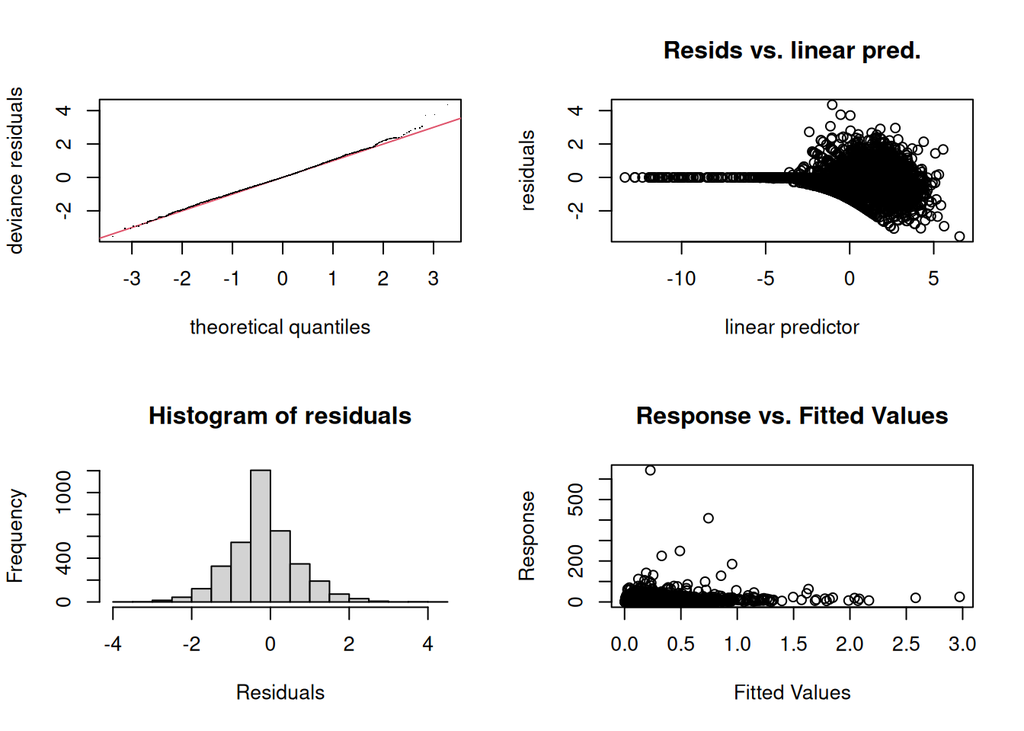

```
Method: REML   Optimizer: outer newton
full convergence after 5 iterations.
Gradient range [1.219139e-06,0.0001299502]
(score 6839.129 & scale 1).
Hessian positive definite, eigenvalue range [2.770904,569.3468].
Model rank =  85 / 85

Basis dimension (k) checking results. Low p-value (k-index<1) may
indicate that k is too low, especially if edf is close to k'.

                       k'   edf k-index p-value
s(WEIGHT_CAND_KG)    9.00  7.77    0.93   0.005 **
s(LISTING_CTR_CODE) 69.00 54.11      NA      NA
---
Signif. codes:  0 '***' 0.001 '**' 0.01 '*' 0.05 '.' 0.1 ' ' 1
```

```r
gam.check(fit_all2)
```

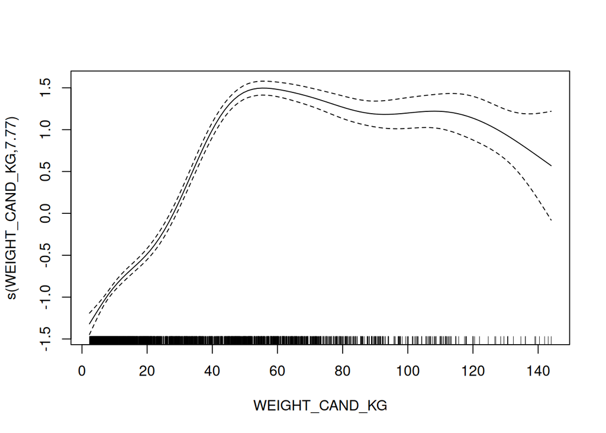

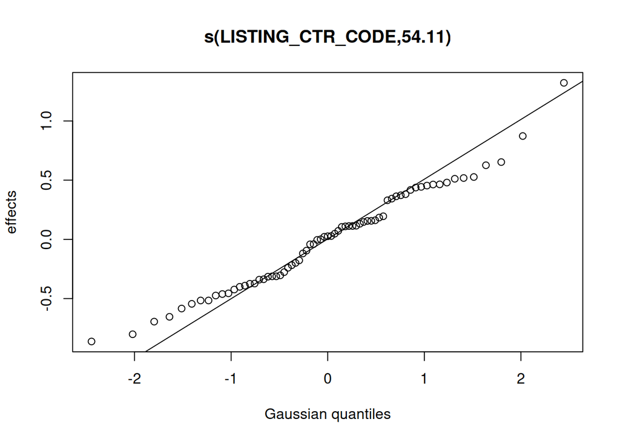

```r
plot(fit_all2)
```

#### Modeling **good** offers

```r
# fit_good = fit_gam("n_good_offers", family = poisson())
# fit_good %>% summary()
# fit_good %>% plot()
```

```r
fit_good2 = fit_gam("n_good_offers", family = nb())
# fit_good2 %>% summary()
# fit_good2 %>% plot()
broom::tidy(fit_good2, conf.int = TRUE, parametric = TRUE)
```

| term | estimate | std.error | statistic | p.value | conf.low | conf.high |
| --- | --- | --- | --- | --- | --- | --- |
| (Intercept) | -2.5668605 | 0.0689487 | -37.2285650 | 0.0000000 | -2.7019974 | -2.4317236 |
| ACCEPT_DCD | 0.2545891 | 0.1265732 | 2.0113974 | 0.0442835 | 0.0065101 | 0.5026680 |
| STATUSStatus 1B | -1.4700949 | 0.0515210 | -28.5339190 | 0.0000000 | -1.5710741 | -1.3691156 |
| STATUSStatus 2 | -3.4348132 | 0.0813019 | -42.2476527 | 0.0000000 | -3.5941619 | -3.2754644 |
| ABO_CANDB | -0.3038963 | 0.0609480 | -4.9861600 | 0.0000006 | -0.4233521 | -0.1844405 |
| ABO_CANDAB | 0.0547415 | 0.1051744 | 0.5204832 | 0.6027268 | -0.1513965 | 0.2608796 |
| ABO_CANDO | -0.6054766 | 0.0435933 | -13.8892125 | 0.0000000 | -0.6909178 | -0.5200353 |

```r
broom::tidy(fit_good2, conf.int = TRUE, parametric = TRUE) %>%
  filter(term == "ACCEPT_DCD") %>%
  transmute(
    rate = exp(estimate) - 1,
    rate_low = exp(conf.low) -1,
    rate_high = exp(conf.high)-1
  ) %>%
  mutate_all(\(x) scales::percent(x, accuracy = 1)) %>%
  gt() %>%
  tab_header(
    title = "good offers: increase in offer rate due to DCD acceptance"
  )
```

good offers: increase in offer rate due to DCD acceptance

| rate | rate_low | rate_high |
| --- | --- | --- |
| 29% | 1% | 65% |

# 5 Demographic Tables for Abstract

We used *Fisher Exact Test* for comparing categorical and binary variables and *Mann-Whitney U Test* for numeric variables.

## 5.1 Waitlist Candidates

Notes:

- The abstract had some variables at transplant. But these are missing for non-transplanted waitlist candidates, so I am only using the values at registration/listing.
- The variables that are only available at transplant E.g., `ICU_AT_TX` and `DIALYSIS`, I set any missing values to No.

```r
candidate_data = read_rds(file.path(dir_data, "data_candidate.rds"))

# candidate_data %>%
#   count(LIFE_SUPPORT_CAND_TX, ECMO_CAND_TX, VAD_CAND_TX, VENTILATOR_CAND_TX, VENT_SUPPORT_TX)


# All pediatric waitlist candidates that were

wl_candidates =
patients %>%
  left_join(WL_DCD, by = "WL_ID_CODE") %>% # add WL_DCD_SEQ
  # filter(
  #   WL_DCD_SEQ %in% c("Yes", "No")
  # ) %>%
  mutate(
    WL_DCD_SEQ_2 = case_match(WL_DCD_SEQ,
                            "No -> Yes" ~ "DBD-L",
                            "Yes -> No" ~ "DCD-L",
                            "Yes" ~ "DCD-L",
                            "No" ~ "DBD-L")
  ) %>%
  transmute(
    WL_ID_CODE,
    WL_DCD_SEQ,
    WL_DCD_SEQ_2,
    AGE_AT_REG = AGE_AT_LISTING,
    AGE_AT_TX,
    STATUS_AT_REG = str_remove(STATUS_AT_LISTING, "HR: "),
    STATUS_AT_TX = str_remove(STATUS_AT_TX, "HR: "),
  ) %>%
  left_join(
    candidate_data %>%
    transmute(
      WL_ID_CODE,
      MALE = 1*(GENDER_CAND == "M"),
      FEMALE = 1*(GENDER_CAND == "F"),
      CHD = 1*(CAND_DIAG == "Congenital Heart Disease"),
      ABO = ABO_CAND,
      WEIGHT = WEIGHT_CAND_KG,
      ECMO_AT_REG = 1*(ECMO_CAND_REG == "Yes"),
      ECMO_AT_TX = 1*(coalesce(ECMO_CAND_TX, ECMO_CAND_REG) == "Yes"),
      VAD_AT_REG = 1*(VAD_CAND_REG == "Yes"),
      VAD_AT_TX = 1*(coalesce(VAD_CAND_TX, VAD_CAND_REG) == "Yes"),
      ICU_AT_TX = 1*(coalesce(MED_COND_CAND_TX, "Unknown") == "ICU"),
      VENTILATOR_AT_REG = 1*(VENTILATOR_CAND_REG %in% "Yes"),
      VENTILATOR_AT_TX = 1*(coalesce(VENTILATOR_CAND_TX,VENTILATOR_CAND_REG) %in% "Yes"),
      #Ventilated2 = VENT_SUPPORT_TX, # Can be VENT_SUPPORT_TX = Yes, but not LIFE_SUPPORT
      DIALYSIS = 1*(coalesce(DIAL_CAND, "Unknown") == "Yes"),
      LIFE_SUPPORT_REG = 1*(LIFE_SUPPORT_CAND_REG == "Yes"),
      LIFE_SUPPORT_TX = 1*(coalesce(LIFE_SUPPORT_CAND_TX,LIFE_SUPPORT_CAND_REG)  == "Yes"),

    ),
    by = "WL_ID_CODE")

# aa %>% mutate_if(is.character, factor) %>% summary()
```

```r
format_pvalue <- function(p){
  case_when(
    p >= 0.01 ~ scales::number(p, accuracy = 1/10^3),
    .default = "< 0.01"
  )
}

make_table_row <- function(data, var, group = WL_DCD_SEQ_2, decimals = 2){
  x = data %>% pull({{group}})
  y = data %>% pull({{var}})
  var_name = data %>% select(any_of({{var}})) %>% colnames()
  # group_name = data %>% select({{group}}) %>% colnames()

  # Mann–Whitney U / Wilcoxon–Mann–Whitney test
  if(is.numeric(y) && n_distinct(y) > 2){
    test = wilcox.test(y~x)
    tab =
      tibble(x,y) %>%
      summarize(
        .by = x,
        median = median(y, na.rm=TRUE) %>% scales::number(accuracy = 10^(-decimals)),
        Q1 = quantile(y, .25, na.rm=TRUE) %>% scales::number(accuracy = 10^(-decimals)),
        Q3 = quantile(y, .75, na.rm=TRUE) %>% scales::number(accuracy = 10^(-decimals)),
        cell = glue::glue("{median} ({Q1}, {Q3})")
      )
    out =
      tab %>%
      select(x, cell) %>%
      pivot_wider(names_from = x, values_from = cell) %>%
      mutate(variable = var_name, x = "", .before = 1) %>%
      mutate(p_value = format_pvalue(test$p.value), test = test$method)

  } else if(all(y %in% c(0,1))){
    # Binary proportion (Use Fisher's Exact Test)
    tab =
      tibble(x,y) %>%
      summarize(.by = x, y = sum(y), n = n()) %>%
      mutate(
        cell = glue::glue("{y} ({scales::percent(y/n, accuracy = 1)})")
      )
    #test = prop.test(x = tab$y, n = tab$n)
    test = fisher.test(table(x,y))
    out =
      tab %>%
      select(x, cell) %>%
      pivot_wider(names_from = x, values_from = cell) %>%
      mutate(variable = var_name, x = "",  .before = 1) %>%
      mutate(p_value = format_pvalue(test$p.value), test = test$method)

  } else {
    # Fisher's Exact Test
    if(nlevels(factor(y)) < 10) test = fisher.test(table(x,y))
    else test = fisher.test(table(x,y), simulate.p.value = 1000)

    tab =
      tibble(x,y) %>%
      count(x,y) %>%
      complete(x,y, fill = list(n = 0)) %>%
      mutate(
        .by = x,
        p = (n / sum(n)) %>% scales::percent(accuracy = 1),
        cell = glue::glue("{n} ({p})")
      )
    out =
      tab %>%
      select(x, y, cell) %>%
      pivot_wider(names_from = x, values_from = cell) %>%
      rename(x = 1) %>%
      mutate(variable = ifelse(row_number() == 1, var_name, ""), .before = 1) %>%
      mutate(
        p_value = ifelse(row_number() == 1, format_pvalue(test$p.value), ""),
        test = ifelse(row_number() == 1, test$method, "")
      )


  }

  return(out %>% select(-test))
}
```

### 5.1.1 Using **Only** Never or Always for DCD Listing

```r
#|output: asis

data =
  wl_candidates %>%
  filter(
    WL_DCD_SEQ %in% c("Yes", "No")
  )

vars =
  data %>%
  select(-WL_ID_CODE, -WL_DCD_SEQ, -WL_DCD_SEQ_2) %>%
  select(-contains("_TX"), ICU_AT_TX) %>%
  colnames() %>%
  set_names()

map(vars, \(var) make_table_row(data, var, group = WL_DCD_SEQ_2)) %>%
  bind_rows() %>%
  add_row(
    variable = "sample size",
    x = "",
    "DBD-L" = str_c("n = ", sum(data$WL_DCD_SEQ_2 == "DBD-L")),
    "DCD-L" = str_c("n = ", sum(data$WL_DCD_SEQ_2 == "DCD-L")),
    p_value = "",
    .before = 1
  ) %>%
  gt()
```

| variable | x | DBD-L | DCD-L | p_value |
| --- | --- | --- | --- | --- |
| sample size |  | n = 2353 | n = 71 |  |
| AGE_AT_REG |  | 5.00 (0.00, 13.00) | 4.00 (0.00, 13.00) | 0.362 |
| STATUS_AT_REG | Status 1A | 1419 (60%) | 51 (72%) | 0.039 |
|  | Status 1B | 502 (21%) | 16 (23%) |  |
|  | Status 2 | 406 (17%) | 4 (6%) |  |
|  | Temporarily Inactive | 26 (1%) | 0 (0%) |  |
| MALE |  | 1311 (56%) | 38 (54%) | 0.718 |
| FEMALE |  | 1042 (44%) | 33 (46%) | 0.718 |
| CHD |  | 1346 (57%) | 37 (52%) | 0.397 |
| ABO | A | 768 (33%) | 24 (34%) | 0.848 |
|  | AB | 80 (3%) | 2 (3%) |  |
|  | B | 322 (14%) | 7 (10%) |  |
|  | O | 1183 (50%) | 38 (54%) |  |
| WEIGHT |  | 19.20 (8.28, 48.30) | 15.30 (6.00, 46.10) | 0.141 |
| ECMO_AT_REG |  | 96 (4%) | 12 (17%) | < 0.01 |
| VAD_AT_REG |  | 524 (22%) | 20 (28%) | 0.249 |
| VENTILATOR_AT_REG |  | 283 (12%) | 17 (24%) | < 0.01 |
| DIALYSIS |  | 37 (2%) | 0 (0%) | 0.626 |
| LIFE_SUPPORT_REG |  | 1210 (51%) | 49 (69%) | < 0.01 |
| ICU_AT_TX |  | 620 (26%) | 27 (38%) | 0.040 |

### 5.1.2 Using DCD Listing at Initial Registration

This is a larger population that uses the DCD listing status at time of listing.

```r
#|output: asis

data =
  wl_candidates

vars =
  data %>%
  select(-WL_ID_CODE, -WL_DCD_SEQ, -WL_DCD_SEQ_2) %>%
  select(-contains("_TX"), ICU_AT_TX) %>%
  colnames() %>%
  set_names()

map(vars, \(var) make_table_row(data, var, group = WL_DCD_SEQ_2)) %>%
  bind_rows() %>%
  add_row(
    variable = "sample size",
    x = "",
    "DBD-L" = str_c("n = ", sum(data$WL_DCD_SEQ_2 == "DBD-L")),
    "DCD-L" = str_c("n = ", sum(data$WL_DCD_SEQ_2 == "DCD-L")),
    p_value = "",
    .before = 1
  ) %>%
  gt()
```

| variable | x | DBD-L | DCD-L | p_value |
| --- | --- | --- | --- | --- |
| sample size |  | n = 2400 | n = 86 |  |
| AGE_AT_REG |  | 5.00 (0.00, 13.00) | 4.00 (0.00, 13.00) | 0.499 |
| STATUS_AT_REG | Status 1A | 1438 (60%) | 63 (73%) | 0.029 |
|  | Status 1B | 517 (22%) | 17 (20%) |  |
|  | Status 2 | 418 (17%) | 6 (7%) |  |
|  | Temporarily Inactive | 27 (1%) | 0 (0%) |  |
| MALE |  | 1339 (56%) | 50 (58%) | 0.740 |
| FEMALE |  | 1061 (44%) | 36 (42%) | 0.740 |
| CHD |  | 1369 (57%) | 46 (53%) | 0.509 |
| ABO | A | 780 (32%) | 28 (33%) | 0.873 |
|  | AB | 81 (3%) | 3 (3%) |  |
|  | B | 328 (14%) | 9 (10%) |  |
|  | O | 1211 (50%) | 46 (53%) |  |
| WEIGHT |  | 19.40 (8.30, 48.40) | 16.75 (6.00, 46.15) | 0.197 |
| ECMO_AT_REG |  | 103 (4%) | 14 (16%) | < 0.01 |
| VAD_AT_REG |  | 533 (22%) | 25 (29%) | 0.147 |
| VENTILATOR_AT_REG |  | 290 (12%) | 20 (23%) | < 0.01 |
| DIALYSIS |  | 39 (2%) | 1 (1%) | 1.000 |
| LIFE_SUPPORT_REG |  | 1232 (51%) | 61 (71%) | < 0.01 |
| ICU_AT_TX |  | 635 (26%) | 32 (37%) | 0.035 |

## 5.2 Transplanted Patients

Restricted to transplants where patient were eligible to receive DCD offers.

This table excludes transplants without follow-up so the sample size matches 3.6.1.

```r
data =
  wl_candidates %>%
  inner_join(
    post_tx %>%
    filter(EV_TIME > 0) %>% # Ignoring tx with no follow-up
    filter(WL_DCD_SEQ %in% c("Yes", "No -> Yes")) %>% # DCD listed candidates
    transmute(
      WL_ID_CODE,
      DCD_DON = case_match(DCD_DON, "N" ~ "DCD-L", "Y" ~ "DCD-R"),
    ),
    by = "WL_ID_CODE"
  )

vars =
  data %>%
  select(
    AGE_AT_TX, FEMALE, CHD, STATUS_AT_TX, ABO, WEIGHT, ECMO_AT_TX,
    VAD_AT_TX, ICU_AT_TX, VENTILATOR_AT_TX, DIALYSIS
  ) %>%
  # select(-WL_ID_CODE, -WL_DCD_SEQ, -WL_DCD_SEQ_2, -DCD_DON) %>%
  colnames() %>%
  set_names()

map(vars, \(var) make_table_row(data, var, group = DCD_DON)) %>%
  bind_rows() %>%
  add_row(
    variable = "sample size",
    x = "",
    "DCD-L" = str_c("n = ", sum(data$DCD_DON == "DCD-L")),
    "DCD-R" = str_c("n = ", sum(data$DCD_DON == "DCD-R")),
    p_value = "",
    .before = 1
  ) %>%
  gt()
```

| variable | x | DCD-L | DCD-R | p_value |
| --- | --- | --- | --- | --- |
| sample size |  | n = 50 | n = 16 |  |
| AGE_AT_TX |  | 12.50 (1.25, 14.75) | 2.50 (0.00, 9.25) | 0.019 |
| FEMALE |  | 27 (54%) | 7 (44%) | 0.570 |
| CHD |  | 18 (36%) | 9 (56%) | 0.242 |
| STATUS_AT_TX | Status 1A | 41 (82%) | 11 (69%) | 0.377 |
|  | Status 1B | 8 (16%) | 4 (25%) |  |
|  | Status 2 | 1 (2%) | 1 (6%) |  |
| ABO | A | 19 (38%) | 3 (19%) | 0.211 |
|  | AB | 0 (0%) | 1 (6%) |  |
|  | B | 6 (12%) | 2 (12%) |  |
|  | O | 25 (50%) | 10 (62%) |  |
| WEIGHT |  | 39.20 (11.44, 64.92) | 12.45 (4.91, 36.10) | 0.014 |
| ECMO_AT_TX |  | 11 (22%) | 0 (0%) | 0.053 |
| VAD_AT_TX |  | 21 (42%) | 8 (50%) | 0.773 |
| ICU_AT_TX |  | 33 (66%) | 9 (56%) | 0.556 |
| VENTILATOR_AT_TX |  | 6 (12%) | 4 (25%) | 0.240 |
| DIALYSIS |  | 1 (2%) | 1 (6%) | 0.429 |

# 6 Listing Centers and DCD

## 6.1 Transplants

```r
DCD_listed =
  patients %>%
  left_join(WL_DCD, by = "WL_ID_CODE") %>%
  summarize(
    .by = LISTING_CTR_CODE,
    n_listed = n_distinct(WL_ID_CODE),
    n_tx = sum(TXED == 1),
    DCD_listed = sum(WL_DCD_SEQ %in% c("Yes", "No -> Yes")),
    DCD_tx = sum(WL_DCD_SEQ %in% c("Yes", "No -> Yes") & TXED & DCD_DON == "Y"),
  ) %>%
  mutate(
    size_rank = min_rank(-n_listed),
    .after = LISTING_CTR_CODE
  ) %>%
  arrange(-n_listed)

DCD_listed
```

| LISTING_CTR_CODE | size_rank | n_listed | n_tx | DCD_listed | DCD_tx |
| --- | --- | --- | --- | --- | --- |
| 19437 | 1 | 126 | 76 | 0 | 0 |
| 19468 | 2 | 118 | 76 | 13 | 5 |
| 13795 | 3 | 98 | 67 | 0 | 0 |
| 00124 | 4 | 97 | 74 | 0 | 0 |
| 00403 | 5 | 86 | 64 | 1 | 0 |
| 13268 | 6 | 83 | 59 | 3 | 0 |
| 00465 | 7 | 78 | 43 | 0 | 0 |
| 00248 | 8 | 75 | 41 | 0 | 0 |
| 23312 | 8 | 75 | 49 | 0 | 0 |
| 02728 | 10 | 71 | 43 | 0 | 0 |
| 15531 | 11 | 70 | 41 | 3 | 0 |
| 18414 | 12 | 67 | 45 | 0 | 0 |
| 05053 | 13 | 60 | 39 | 0 | 0 |
| 13485 | 13 | 60 | 45 | 0 | 0 |
| 20677 | 15 | 58 | 50 | 0 | 0 |
| 20863 | 15 | 58 | 33 | 0 | 0 |
| 00279 | 17 | 57 | 40 | 4 | 0 |
| 04464 | 18 | 56 | 37 | 40 | 10 |
| 06417 | 19 | 55 | 42 | 0 | 0 |
| 25841 | 19 | 55 | 34 | 1 | 0 |
| 23901 | 19 | 55 | 33 | 17 | 3 |
| 26537 | 22 | 52 | 31 | 0 | 0 |
| 08277 | 22 | 52 | 28 | 3 | 0 |
| 03813 | 24 | 50 | 42 | 0 | 0 |
| 09362 | 25 | 49 | 41 | 2 | 0 |
| 03906 | 26 | 48 | 24 | 0 | 0 |
| 00868 | 27 | 40 | 18 | 0 | 0 |
| 02976 | 28 | 39 | 25 | 0 | 0 |
| 10478 | 29 | 38 | 21 | 19 | 2 |
| 05642 | 29 | 38 | 28 | 0 | 0 |
| 08494 | 31 | 34 | 24 | 0 | 0 |
| 15159 | 32 | 33 | 23 | 12 | 1 |
| 25518 | 32 | 33 | 16 | 0 | 0 |
| 12524 | 34 | 31 | 17 | 0 | 0 |
| 05890 | 35 | 30 | 20 | 0 | 0 |
| 02883 | 36 | 29 | 21 | 0 | 0 |
| 06820 | 37 | 27 | 14 | 0 | 0 |
| 01271 | 38 | 24 | 8 | 0 | 0 |
| 07471 | 38 | 24 | 15 | 0 | 0 |
| 05704 | 40 | 23 | 16 | 0 | 0 |
| 22878 | 40 | 23 | 13 | 0 | 0 |
| 19034 | 42 | 22 | 16 | 0 | 0 |
| 15872 | 43 | 20 | 10 | 0 | 0 |
| 05549 | 44 | 19 | 13 | 0 | 0 |
| 02666 | 45 | 16 | 7 | 0 | 0 |
| 22289 | 46 | 15 | 11 | 0 | 0 |
| 25711 | 46 | 15 | 9 | 0 | 0 |
| 06572 | 48 | 11 | 6 | 0 | 0 |
| 07347 | 48 | 11 | 7 | 0 | 0 |
| 25110 | 50 | 10 | 3 | 0 | 0 |
| 04712 | 50 | 10 | 7 | 0 | 0 |
| 02418 | 52 | 8 | 3 | 0 | 0 |
| 06603 | 53 | 7 | 2 | 0 | 0 |
| 07905 | 53 | 7 | 4 | 0 | 0 |
| 04557 | 55 | 6 | 4 | 0 | 0 |
| 25657 | 56 | 5 | 1 | 0 | 0 |
| 23467 | 56 | 5 | 0 | 0 | 0 |
| 04774 | 58 | 4 | 2 | 0 | 0 |
| 22692 | 58 | 4 | 4 | 0 | 0 |
| 19499 | 58 | 4 | 1 | 0 | 0 |
| 21080 | 61 | 3 | 0 | 0 | 0 |
| 11129 | 62 | 2 | 2 | 0 | 0 |
| 11935 | 63 | 1 | 1 | 0 | 0 |
| 11749 | 63 | 1 | 1 | 0 | 0 |
| 14942 | 63 | 1 | 0 | 0 | 0 |
| 16523 | 63 | 1 | 1 | 0 | 0 |
| 13609 | 63 | 1 | 1 | 0 | 0 |
| 03503 | 63 | 1 | 1 | 0 | 0 |
| 15283 | 63 | 1 | 0 | 0 | 0 |

There were 12 centers that listed DCD candidates out of 69 centers that listed pediatric HR candidates.

There were 5 centers that Transplanted DCD Donors out of 12 centers that listed DCD candidates.